# Assignment 3: Dissipative Particle Dynamics

**6EMA02 Particle-based Simulations, 2026-2027 edition** Mesoscale simulation · soft repulsive beads · demixing and interfaces

## How this assignment is assessed: read this first

This notebook is both the assignment text and your report. Task cells (like this one) are the assignment text and are marked read-only. Jupyter enforces that; some editors (VS Code among them) do not, so simply leave them untouched either way: hand-ins are checked against the released notebook, and modified task cells are flagged. You write your answers in the cells below each task and hand in this same notebook, **executed**, together with an HTML export, your code, and the data files the notebook loads (layout at the end of this notebook).

Your report is **not graded on its content**. Its result is determined in the individual oral examination at the end of the quartile: the exam is a conversation about *your* code and *your* results, with this notebook on screen. Write it as your defence dossier: concise, bullet answers are fine, every claim something you can stand behind. A report you never hand in scores 0 for its weight in the final grade; a handed-in report's result *is* your oral grade.

**AI and sources.** You may use AI assistants (ChatGPT, Claude, Copilot, …) freely in this course, for code, analysis, and text. Declare the use briefly in the *Sources* section below, along with any other external sources: anything in your submission (code, text, data, results) that your group did not produce itself. Declared sources are never penalised: nobody grades the text of your report or the style of your code. The oral examination assesses what *you* understand about the simulation you hand in. Anything in your submission is fair game, and "we didn't write that part" is not an available answer. Presenting undeclared external work as your own is academic misconduct and is treated as such.

## Group

- **Group ID:** group_A3_5 (A3 group 5)
- **Members:** Thierry Quintius (2567296); Tijn Schils (1893521).

Group name and membership checked in the Canvas A3 group roster on 15 October 2026. Canvas user IDs in profile URLs are not student numbers.

## The physics: why a mesoscale method exists

Your A2 code integrates the motion of individual molecular sites with a time step of about a femtosecond. Now consider what you would need to simulate a droplet of oil in water demixing, or a polymer solution flowing through a channel: micrometres of space and microseconds of time. That is roughly $1012$ sites and $109$ steps. Molecular dynamics cannot get there, and continuum fluid mechanics cannot resolve the individual polymer chains that matter. **Dissipative particle dynamics (DPD) lives in that gap.**

The trick is **coarse-graining**. One DPD bead is not an atom: it stands for a lump of fluid, a cluster of molecules moving together. Because a bead is a soft blob rather than a hard molecule, two beads may overlap, and the repulsion between them is **soft**:

$$𝐅ijC=aij(1−rijrc)𝐫^ijfor rij<rc,$$

finite even at $rij=0$. No $r−12$ wall means no violently fast collisions, which is what buys the very large time steps that make the method useful.

Coarse-graining throws away degrees of freedom, and they must come back as noise and friction. DPD adds two more pair forces:

$$𝐅ijD=−γωD(rij)(𝐫^ij·𝐯ij)𝐫^ij,𝐅ijR=σωR(rij)ζijΔt𝐫^ij.$$

The dissipative force damps the *relative* velocity of a pair, the random force kicks it. Neither is arbitrary: the **fluctuation-dissipation theorem** ties their amplitudes and their weight functions together (Eq. (5) of the paper, with $ωD=[ωR]2$ and $σ2=2γkBT$). Get that relation wrong and your system simply equilibrates to the wrong temperature, which is exactly what task B3 checks.

The decisive property is that **all three forces act pairwise along the line between beads**, so they conserve momentum. That is the difference between DPD and Brownian or Langevin dynamics, where the friction is with an implicit background that absorbs momentum. Conserved momentum means the correct long-wavelength behaviour emerges by itself: DPD reproduces hydrodynamics, so a DPD fluid flows, carries shear, and mediates hydrodynamic interactions between suspended objects. That is what makes it a *mesoscale* method rather than a fast approximation.

What does a bead stand for, quantitatively? Groot and Warren fix that by matching the compressibility of water at $ρ=3$, giving $aii≈25kBT/rc$ for beads of the same type. Different types repel more strongly, $aij>aii$, and the excess drives demixing. The link to polymer physics is the Flory-Huggins parameter $χ$, which you will measure in task C3 and which turns out to depend linearly on $Δa=aAB−aAA$. Add springs between beads and you have polymer chains, whose demixing at much smaller $Δa$ (the $χN$ of Eq. (27)) is the subject of Part D.

## What you will do, and the reference paper

You will convert **your own MD code from Assignment 2** into a DPD code, verify it, and then use it to reproduce published results. There is no new starting code for A3, and so no `\todo` list to guide you: everything you have to build is stated in this notebook, in the section *From your A2 code to a DPD code* below and in the task texts. Read both before you change a line.

The reference is Groot and Warren, *J. Chem. Phys.* **107**, 4423 (1997), handed out under Files ▸ Papers. Equation and figure numbers in this notebook refer to that paper. Reproducing a published result is the strongest form of validation available to you here: the numbers exist independently of your code, so agreement is evidence and disagreement is information.

**Units: not the units of A2.** In A2 the energy unit was $kB×1$ K, lengths were in Å and masses in amu, so $kBT=293$, the masses were about 15, the cut-off was 14 and the time step 0.001 (about 1 fs). DPD uses its own reduced units: the cut-off distance $rc$ of the DPD interactions is the unit of length, the bead mass $m$ the unit of mass, and the thermal energy $kBT$ the unit of energy. The time unit follows as $rcm/kBT$. So $rc=m=kBT=1$, and **every number in your A2 `setparameters.c` changes**; the table in the next section lists them. Report everything in these units unless you say otherwise.

**The integrator stays.** Groot and Warren's Eq. (9) is a velocity-Verlet step in which the velocity-dependent forces of the new time step are evaluated with a predicted velocity $𝐯~=𝐯(t)+λΔt𝐟(t)/m$. Your A2 loop already does this with $λ=1/2$: it calls `calculate_forces` after the first half kick and the position update, so the velocities the force routine sees are exactly $𝐯(t)+12Δt𝐟(t)/m$. Keep the loop as it is. Use $Δt=0.04$ for all thermostatted runs, as the paper does.

Expect the conversion to be where the bugs are. Take small steps, run a short simulation after each change, and look at it in OVITO before you measure anything.

**Your working environment** is the one you set up for A1 and A2: the `pbs-env` environment from `requirements.txt`, `nb2html.py` for the HTML you hand in, and `check_my_submission.py` before you submit. See the Canvas page *Working on the assignments*.

## From your A2 code to a DPD code

This is the inventory: what you can keep, what you must change, and what you must write from nothing. Names refer to the A2 starting code; if you renamed things in A2, map them onto your own.

**Keep as it is.** The velocity-Verlet loop in `main.c` and the two routines in `dynamics.c` it calls (`update_velocities_half_dt`, `update_positions`); `boundary_conditions`; the cell list and neighbour list in `nbrlist.c`; `v3_min_image` and the other vector helpers; the restart files; the bond list built in `initialise_bond_connectivity` and `initialise_structure`; and the finite-difference force test. The test still works for the conservative force and the springs, which derive from a potential, provided you switch the dissipative and random forces off while it runs; it cannot test those two, which derive from no potential.

**Change.**

| A2 | A3 |
| --- | --- |
| $kBT=293$, masses 15.035 and 14.027 | $kBT=1$, both masses 1 |
| `r_cut = 14`, `r_shell = 1` | `r_cut = 1`, `r_shell` about 0.3 to 0.4 |
| `dt = 1e-3` | `dt = 0.04` (task B1 uses smaller values) |
| cubic box from the mass density | box in units of $rc$, `num_part` $=ρLxLyLz$ with $ρ=3$ (see the run plan) |
| Lennard-Jones $ϵij$, $σij$ per type pair | DPD repulsion $aij$ per type pair; two types, A and B |
| bond $12kb(r−r0)2$, $r0=1.54$ | the same routine with $r0=0$ and $kb=C=2$: that *is* Eq. (25) |
| angle and torsion terms | **removed**: delete their calls from `calculate_forces`. `initialise_structure` derives angles and dihedrals from the bonds by itself, so leaving the calls in applies pentane angle and torsion forces … |
| `factor_12_nb = factor_13_nb = factor_14_nb = 0` | **all three equal to 1**: in DPD bonded beads also repel each other (task A2) |
| CH$3$ and CH$2$ in fixed pentane order | type A or B per chain, a chosen fraction of each (task A2) |
| 5 sites per molecule, 4 bonds | chains of $N$ beads, $N−1$ bonds; $N=1$ means no bonds at all |
| pentanes on a lattice | random-walk chains, optionally A and B in separate halves of the box (task A2, Part C) |
| Berendsen thermostat, `is_NVT = 1` | **removed**: the dissipative and random forces are the thermostat, and rescaling the velocities on top of them destroys the fluctuation-dissipation balance they rely on |
| output and sampling intervals, in steps | check each one: a step is now $0.04$ time units, not 1 fs |
| `record_trajectories_pdb` labels every site C | OVITO then sees one particle type. If your A beads come first, colour by index: *Expression selection* with `ParticleIndex <` (number of A beads), then *Assign color*. Otherwise write the type into th… |

**Write new.**

- The three DPD pair forces in `calculate_forces_nb` (task A1). They need the velocities and the time step, which the Lennard-Jones loop never used, and a source of random numbers.
- Two switches in `setparameters.c`, one for the conservative force and one for the dissipative and random forces together. Part B runs with each of them off in turn.
- On-the-fly analysis, most of it new: $g(r)$ per type pair (A3); the velocity distribution (B3), which you may already have from A2; the composition profile along $x$ (Part C); the diagonal components of the pressure tensor (C4); the end-to-end distance of the chains (D1).

## The runs, at a glance

Every run is a separate compilation with its own `setparameters.c` values, as in A2. Density $ρ=3$ throughout and $aAA=aBB=25$; $Δa=aAB−25$. The step counts are a suggestion that is known to be enough. For orientation, a reference DPD code of the same structure as yours does 60 000 steps of 6000 beads in about five minutes on one core.

| runs | box | beads | $N$ | $aAB$ | switches, $Δt$ | steps | tasks |
| --- | --- | --- | --- | --- | --- | --- | --- |
| energy | $103$ | 3000 | 1 | 25 | dissipative and random **off**; $Δt$ = 0.04, 0.02, 0.01, 0.005; start from the end of the monomer-fluid run | to $t=200$ | B1 |
| ideal gas | $103$ | 3000 | 1 | 25 | conservative **off** | 20 000 | B2, B3 |
| monomer fluid | $103$ | 3000 | 1 | 25 | all on | 20 000 | B3, C1 |
| Fig. 6 | $20×10×10$ | 6000 | 1 | 37 | all on, separated start | 60 000 | C2 |
| χ series | $20×10×10$ | 6000 | 1 | 35, 39, 43, 47 | all on, separated start | 60 000 each | C3, C4 |
| control | $20×10×10$ | 6000 | 1 | 25 | all on, separated start | 60 000 | C4 |
| chains | $103$ | 3000 | 5 | 25 | all on | 20 000 | D1 |
| chain demixing | $20×10×10$ | 6000 | 3, 5, 10 | 28 | all on, separated start | 60 000 each | D2, D3 |
| chain χ series | $20×10×10$ | 6000 | 3; 5; 10 | 30, 32; 27, 28.5, 30; 26, 26.5, 27 | all on, separated start | 60 000 each | D3 |

Long runs are done in the terminal, never from the notebook; let the notebook load their output from `data/`.

## Code map: fill in as you go

The links below point to the implementation and saved evidence for each task. All paths are relative to this notebook and are included in the submission zip. Analysis is performed in the executed notebook cells; the linked Python scripts also provide standalone analysis and recorded run settings.

| Task | File / function(s) | Data files |
| --- | --- | --- |
| A1 DPD forces | `calculate_forces_nb`, `dpd_noise`; force checks | Mac checks; smoke thermodynamics |
| A2 bead-spring chains, initialisation | `initialise_types`, `initialise_bond_connectivity`, `initialise_positions`; `calculate_forces_bond` | chain checks; smoke configuration |
| A3 g(r) | `rdf_sample`, `analysis_update`, `analysis_finish` | uniform RDF; uniform RDF blocks; smoke RDF |
| B1 energy conservation | integration loop; `calculate_forces_nb`; `record_to_csv`; analysis | dt=0.04; dt=0.02; dt=0.01; dt=0.005; drift table |
| B2/B3 ideal gas and velocity distribution | `rdf_sample`; `velocity_update`, `velocity_finish`; B2 analysis; B3 analysis | ideal RDF; ideal velocity histogram; fluid velocity histogram; temperature table |
| C1 monomer RDF | `rdf_sample`; notebook analysis | fluid RDF; RDF blocks; Fig. 2 reference |
| C2/C3 composition profile, χ | `slab_update`, `slab_finish`; notebook profile and χ analysis | C2 blocks; aAB=35; aAB=39; aAB=43; aAB=47; χ table |
| C4 pressure tensor, surface tension | conservative virial; `slab_update`; notebook tension analysis | aAB=35; aAB=39; aAB=43; aAB=47; control; tension table |
| D1 chain size | `chain_re2`, `chainstats_update`; periodic-boundary test; `d1` | chain blocks; chain-size table; OVITO snapshot; run manifest |
| D2 two-phase chains | `slab_update`; `d2`; OVITO renderer | N=3 profile; N=5 profile; N=10 profile; diagnostics; render provenance |
| D3 χ for chains | `chiN`, `diagnostics`, `d3`; run settings | χ and χN table; reblocking errors; all nine profiles; published mapping source |

## Implementation status

Part A checks passed. Part B and C results are retained from the repository; a review found that the B prose tables need refreshing against the saved data, and C2's convergence claim needs care. Part D code, saved runs and analysis have now been added in the answer cells below. The Canvas group name and members are now recorded. Both student numbers are recorded in the local submission copy. The group’s review of the lessons-learned draft is still required. On 16 October 2026, the rebuilt submission zip passed the course check_my_submission.py checks against the unmodified downloaded A3 notebook: layout, task cells, execution, relative links, HTML formulas and C compilation.

## Sources

**AI tools used:** OpenAI ChatGPT/Codex.

**Used for:** converting the group's uploaded `A2-11.zip` source to DPD for A1–A3; writing the implementation notes, focused checks, analysis and this working package. The AI initially executed the checks and short smoke run on Linux. The user then compiled and ran the same code on the Mac; those uploaded data now supply the figures. The AI refreshed the notebook and HTML from them. This does not imply that the group has reviewed or understood every change.

**Other external sources:** the provided A3 assignment notebook; Groot, R. D. and Warren, P. B., *Dissipative particle dynamics: Bridging the gap between atomistic and mesoscopic simulation*, J. Chem. Phys. **107**, 4423–4435 (1997), provided PDF, especially Eqs. (3)–(9), (15), (25), and the discussion of uniform noise on p. 4426. The attractive spring sign follows the assignment correction. The underlying MD program is the PBS course code attributed to E. A. J. F. Peters, J. T. Padding and Jeroen Hofman, extended by the group for A2.

**Parts with substantial external/AI content:** the modified/new C code, `code/tests/`, Part A notes and verification cells. Task cells are unmodified.

**Verification performed by the AI:** analytical pair checks; finite differences for the conservative and spring terms; virial check; noise moments; N=1,3,5,10 chains; momentum and neighbour/all-pairs comparisons; uniform-configuration RDF normalisation; restart round trip; address/undefined-behaviour checks; a 1000-step DPD run. Logs are included.

**Verification performed by the user:** compiled with `gcc -O3 *.c -o dpd -lm`, ran the 1000-step simulation, and ran `sh tests/run_checks.sh` on the M1 Mac; all checks passed. Opened `a_smoke.pdb` in OVITO Basic 3.16.1 and confirmed playback. The screenshot showed the trajectory loaded with two bead colours and five frames. No full defect inspection or equilibration claim is made. Mac session record, Mac test transcript.

**Still to do by the group:** read and explain the implementation and its limitations for the oral, resolve the documented B/C and D qualifications, and review the lessons learned. The course export and submission-structure checks were completed on 16 October 2026; these checks do not certify the scientific conclusions.

**Part D update (2026-10-15):** OpenAI Codex added end-to-end chain-size sampling, a periodic-boundary fixture, the Part D runner, analysis, snapshot rendering and report text. It ran the new cases on the local Mac and checked existing force/chain tests. D snapshots are rendered from the saved final PDB coordinates with OVITO/OSPRay. Blue denotes A and orange denotes B. See `scripts/render_d_ovito.py` and `data/D_ovito_render_manifest.json`. The reference Eq. (27) was checked in the author-uploaded paper. The group must review and understand these additions before the oral. See `RUN_LOG_PartD.md` for exact commands and `data/*_manifest.json` for run provenance.

**Snapshot rendering update (2026-10-15):** Codex rendered the same final saved configurations with OVITO 3.14.1 / OSPRay on Linux. No simulations or numerical measurements were rerun. The four embedded D snapshots and their captions were updated.

## Build & run log

The first entries below record the historical Part A verification. B and C production results are retained from the repository, and the Part D production update is recorded at the end of this section.

**Mac run supplying the current figures and data (2026-10-08):** M1 MacBook Air, ARM64, macOS 27.0.1. The user executed these commands from `~/Downloads/A3_PartA/code`; the current compiler version was not re-queried.

```
gcc -O3 *.c -o dpd -lm
time ./dpd > ../data/a_smoke_run.log 2> ../data/a_smoke_stderr.log
tail -n 3 ../data/a_smoke_thermo.csv
sh tests/run_checks.sh
```

The smoke run took **3.841 s wall time**, 3.31 s user and 0.03 s system, as printed by the shell. That timing appeared in Terminal rather than the redirected stderr file; a_smoke_stderr.log is empty. The final temperature is **1.015042985** at step 1000 (time 40). The user uploaded the resulting data folder. The unredirected test output was pasted into the conversation and is preserved as a labelled Mac test transcript, not presented as a shell-generated log. The Mac session record contains the exact commands, timing and final rows supplied by the user.

**Initial assistant verification (Linux):** Codex, 2026-10-08, Linux x86_64, GCC 13.3.0. Commands executed from `code/`:

```
gcc -O3 *.c -o /tmp/dpd_a3 -lm
{ time /tmp/dpd_a3 > ../data/a_smoke_run.log; } 2> ../data/a_smoke_stderr.log
{ time sh tests/run_checks.sh > ../data/a_checks.log; } 2> ../data/a_checks_stderr.log
ASAN_OPTIONS=detect_leaks=0 CFLAGS='-O1 -g -fsanitize=address,undefined -fno-omit-frame-pointer -Wall -Wextra' sh tests/run_checks.sh > ../data/a_sanitizer.log 2> ../data/a_sanitizer_stderr.log
```

The initial Linux smoke run took about 3 seconds, and the focused checks about 1 second including compilation. A warning build with `gcc -O3 -Wall -Wextra -Wpedantic *.c -o /tmp/dpd_a3 -lm` was also clean. The original Linux test log, test timing, sanitizer log and sanitizer stderr are retained as historical checks. The Mac run overwrote the smoke files and the uniform/small-box RDF files; those current files are **Mac data**. The sanitizer run was performed on Linux, not on the Mac. Leak detection was disabled because LeakSanitizer could not inspect processes in that environment. No leak-check pass is claimed. The source code uploaded from the Mac matches the previously checked implementation byte for byte.

**Smoke parameters:** 3000 monomers, 1500 A/1500 B, L=(10,10,10), ρ=3, aAA=aAB=aBB=25, γ=4.5, σ=3, kBT=m=rc=1, dt=0.04, seed=13; uniform initial positions, initial centre-of-mass momentum removed. 1000 steps (time 40), thermodynamics every 50 steps, PDB every 250 steps. RDF discards steps ≤250 and samples every 25 steps, 250-step blocks: 30 frames in 3 blocks. This short discard is not an equilibration assessment. The exact configuration is setparameters.c.

**Uniform RDF check:** 500 independent monomers per frame, 150 A/350 B, box 10³, 100 independently resampled configurations, 10 frames per block, dr=0.02, rmax=3. There is no integration in this check. See test_dpd.c. A box-6 check also exercises the small-box fallback. Seed 13 is reinitialised by the fixture; `rand()` differs across platforms, so the Mac values need not equal the Linux values.

**OVITO:** on 2026-10-08 the user loaded a_smoke.pdb in OVITO Basic 3.16.1 and confirmed particle motion during playback. A is displayed as grey C-labelled beads and B as red O-labelled beads. These are display labels, not chemical identities. Five saved frames confirm file readability and motion, not full validation of dynamics or equilibrium.

**Notebook refresh:** Codex re-executed the saved-data analysis in a persistent in-process IPython session using the uploaded Mac files and exported HTML using nbconvert. No simulation was rerun to replace the user's data. The course's `nb2html.py` and `check_my_submission.py` were not supplied and remain to be used on the finished assignment before submission.

**Part D production update (2026-10-15):** See `RUN_LOG_PartD.md`. Twelve distinct production systems were run: D1 plus eleven demixed systems; one demixed case serves both D2 and D3. The statements above describing a Part-A-only version are historical. The new notebook analysis reads saved output and does not launch simulations.

**Submission repair and checks (2026-10-16):** Restored the Code map with relative links to code and data, retained the implementation-status notes separately, and made notebook data paths explicitly relative to its root. All ten code cells were rerun from saved data; no production simulations were rerun. All D1/D2/D3 numerical tables reproduce the previous values. Exported with the course `nb2html.py` (337 MathML formulas, zero failed conversions). The course `check_my_submission.py` passed for `group_A3_5_A3.zip` against the unmodified downloaded release notebook: all 18 task cells match, every referenced file is present, and C compilation has zero warnings. B/C scientific issues and the group’s own first-bug reflection remain separate from these structural checks.

## Part A: Implementing the DPD method

*In the oral you should be able to:* explain each of the three DPD pair forces and what it does to the system's energy and momentum; explain the $1/Δt$ in the random force; explain why σ and γ are not independent, and why the Berendsen thermostat had to go.

### A1) DPD pair forces

Replace the Lennard-Jones interaction in `calculate_forces_nb` by the DPD pair forces of Eqs. (3), (4) and (8): the conservative force $𝐅C$, the dissipative force $𝐅D$, and the random force $𝐅R$, with the weight functions of Eq. (6) and all three zero beyond $rc$. Use $γ=4.5$ and derive $σ$ from the fluctuation-dissipation relation, Eq. (5). For the random force use $ζij$ with mean zero and variance 1; uniformly distributed numbers from $[−3,3]$ are recommended (see the discussion on p. 4426 of the paper). Make the conservative force type-dependent, $aij$ per pair of types, stored the way A2 stored $ϵij$.

The potential energy your routine returns is that of the conservative force alone: the other two derive from no potential. Accumulate the virial from the conservative force only, as in the second line of Eq. (15).

Document in the cell below: the value of $σ$ you derived and from which relation; how you ensured that $ζij=ζji$ for a pair (what would break if it were not?); and where in your step the random force is drawn, given that it depends on $Δt$.

*Implementation notes (A1):*

Let $rij=ri−rj$ (minimum image), $r^ij=rij/r$, $vij=vi−vj$, and $w=1−r/rc$ for $r<rc$. The pair loop adds

$$FC=aijwr^ij,FD=−γw2(r^ij·vij)r^ij,FR=σwζijΔt−1/2r^ij.$$

All three vanish for $r≥rc$. Eq. (5) requires $σ2=2γkBT$, so $σ=2(4.5)(1)=3$; Eq. (6) requires $wD=(wR)2$. The noise is uniform on $[−3,3]$: its mean is zero and variance is $(23)2/12=1$. The random *impulse* is proportional to $Δt$, so its variance scales as elapsed time. Omitting $1/Δt$ would make the effective noise strength change incorrectly with the integration step.

Each unordered pair appears once in the neighbour list. We draw one scalar, construct the combined force, and add it to i and subtract it from j. This implements $ζij=ζji$ and conserves pair momentum. Drawing independent noise separately for the two directions would cause a random net force and centre-of-mass drift. Forces are central, hence also give zero pair torque.

The initial force is drawn before the loop. In each step there is one new draw per interacting pair after the half kick, drift, wrapping and neighbour update. The dissipative force therefore sees predicted velocities with $λ=1/2$. The final half kick and the next step's first half kick reuse the stored force; neither draws extra noise. The Berendsen thermostat is removed: D dissipates relative radial kinetic energy and R replenishes it with the linked noise strength. An additional velocity rescaling would modify this balance.

C is switched independently of D+R. The returned pair potential is only $UC=12aijrc(1−r/rc)2$ inside the cutoff, zero outside. The pair virial is only $rij·FC$; the total potential and virial additionally include springs. D/R have no potential. Total energy is therefore not conserved with the thermostat on, while pair momentum is.

Tests in Mac check transcript cover every pair type and switch combination, cutoff and periodic image, dissipative sign, momentum, and exclusion of D/R from potential/virial. The finite-difference relative errors are about $1.4×10−10$ for both C and springs and $5.6×10−11$ for the virial. D/R are switched off for these energy-derivative tests. The 200000-draw noise check reports its mean and variance below. At exactly coincident nonbonded bead centres the direction is undefined; the code stops with an explicit error.

### A2) Bead-spring chains

Adapt the code to chains of $N$ beads: `initialise_bond_connectivity` must bond bead $k$ to bead $k+1$ within each chain, and `initialise_types` must give all beads of a chain the same type, A or B. The spring force between bonded beads is

$$𝐟ij=−C𝐫ij,C=2kBTrc−2$$

(note the sign error in the paper's Eq. (25); the spring is always attractive). This is your A2 bond force with rest length zero.

Bonded pairs must **also** interact through the DPD pair forces. In A2 the excluded pairs would have overlapped the steep Lennard-Jones core, and the bonded terms already described their interaction. Neither holds here: the DPD repulsion is soft, and a chain bead is the same bead as a monomer, with the same repulsion from every neighbour. In the A2 code that means setting `factor_12_nb`, `factor_13_nb` and `factor_14_nb` to **one**, the opposite of A2: a factor zero excludes a pair, and a factor one treats it like any other pair (and skips the connectivity lookup altogether).

Write an initialisation for chain systems that avoids overstretched springs, for instance each chain as a random walk with steps of about the mean bond length. Give it an option to start all A chains in the half $x<Lx/2$ and all B chains in $x>Lx/2$, which every demixing run of Parts C and D uses.

Document your initialisation, and state what would go wrong physically if 1-2 and 1-3 pairs *were* excluded here, given that this is the opposite of what you did in A2.

*Implementation notes (A2):*

initialise.c partitions the bead array into consecutive chains of `chain_length` beads. Each chain has N−1 consecutive bonds and one type. The number of A chains is the nearest integer to `fraction_A * number_of_chains`; the first chains are A and the rest B. The total bead count must be divisible by N. For N=1 there are no springs. The original topology builder still derives angles/dihedrals, but no angle or torsion force is called.

Each chain starts at a uniform position and grows as an isotropic random walk with steps of 0.8 rc. Directions use uniform cos θ and azimuth, not uniform θ. Positions wrap periodically. With `separated_start=1`, A starts in x<Lx/2 and B in x>Lx/2; proposed steps entering the other half are rejected. This avoids starting bonds stretched across the box. The rejection near the interface biases the initial conformations, so this is an initial condition, not an equilibrium sample. The fixed initial step length is not the spring's rest length.

The spring potential is $Ub=12Cr2$, hence $Fij=−Crij$ with C=2, explicitly attractive. Evaluating it without dividing by r also makes the spring well-defined at zero separation. The factors for 1–2, 1–3 and 1–4 pairs are all 1: connected beads still receive C, D and R pair forces. Excluding 1–2 pairs would remove the soft repulsion balancing the attractive spring and favour shorter bonds; excluding 1–3 pairs would also change local chain conformations and intrachain structure. Neither repulsion is supplied by another potential here.

The checks cover N=1,3,5,10, both initialisation modes, bond/angle/dihedral counts, homogeneous chain types, initial bond lengths, 50 integration steps per fixture, and conserved total momentum. Conservative forces after those steps are compared with a fresh all-pairs calculation. A two-bead test verifies that its spring energy **and** its DPD repulsion are both present. Checks.

### A3) Radial distribution function

Implement on-the-fly calculation of the radial distribution function $g(r)$, per type pair (AA, AB, BB), up to $r=3$. State your bin width and the normalisation you used, and how you convinced yourself the normalisation is right (a run whose answer you know in advance is the cheapest way; task B2 gives you one).

*Implementation notes (A3):*

The RDF has 150 bins of width Δr=0.02, from 0 to 3. For each sampled configuration, analysis.c counts each unordered pair once, including intrachain pairs, using minimum-image separation. The force neighbour list only reaches rc+r_shell=1.4, so it cannot supply the full RDF. A separate list reaching 3 is rebuilt for RDF sampling. If the box cannot support three RDF cells per direction, an exact i<j loop is used. In both cases rmax must not exceed half the shortest box length. Sampling neither changes the force list nor draws RNG values.

For M frames and an exact shell volume $ΔVb=4π3(rb+13−rb3)$,

$$gαβ(rb)=Hαβ,bMPαβΔVb/V,PAA=NA(NA−1)2,PAB=NANB,PBB=NB(NB−1)2.$$

The finite-N pair counts account for self exclusion and the once-per-pair convention. No additional factor of two is applied to AB. If a pair population is absent, g is undefined and written as NaN. Block histograms and sample counts are saved, as well as the total histogram.

For a known answer, the check generates 100 independent uniform configurations in a periodic box, with unequal type counts (150 A, 350 B) to exercise all three normalisations. Every RDF count in the first configuration is compared with a brute-force i<j loop. The shell-volume-weighted g between r=0.5 and 3 is approximately 1.00098 (AA), 0.99982 (AB), 0.99923 (BB) on the Mac, consistent with the expected 1. The block comparison is plotted below. This is a direct geometric normalisation check, **not** the thermostatted ideal-gas trajectory still required for B2.

The default short DPD smoke run also produces an RDF, but its 30 sampled frames are not presented as a converged result or a reproduction of the paper. Its thermodynamic trace is included solely to check finite output and relaxation.

```python
%matplotlib inline
from pathlib import Path
import numpy as np
import matplotlib.pyplot as plt

log = Path("data/a_mac_checks_transcript.log").read_text()
assert "ALL PART A CHECKS PASSED" in log
print(log)
print("Earlier Linux sanitizer stderr:", repr(Path("data/a_sanitizer_stderr.log").read_text()))
```

```
Mac Terminal output pasted by the user in this conversation, 2026-10-08.
Command: sh tests/run_checks.sh
This is a transcript, not a log redirected by the shell.

PASS pair forces, switches, types, cutoff, periodicity, momentum, conservative-only energy/virial
Particle 0: Force analytical: (8.36306, 12.5446, 4.18153), Force FD: (8.36306, 12.5446, 4.18153), rel.err=1.42866e-10
Particle 0: Force analytical: (-0.4, -0.6, -0.2), Force FD: (-0.4, -0.6, -0.2), rel.err=1.4301e-10
Virial test: analytical W = 5.57414, finite-difference W = 5.57414, rel.err=5.58687e-11
PASS finite-difference conservative/spring forces, virial, bonded repulsion, zero-length spring
Noise samples=200000 mean=-0.00111879993 variance=0.997469268
PASS uniform noise moments
PASS chains N=1,3,5,10; homogeneous/separated starts; lengths; 50-step dynamics; momentum; neighbour forces vs all pairs
Uniform integrated g[0] for 0.5<=r<3: 1.00097653
Uniform integrated g[1] for 0.5<=r<3: 0.999822139
Uniform integrated g[2] for 0.5<=r<3: 0.999230453
RDF: 100 frames, 10 blocks, dr=0.02, rmax=3, NA=150, NB=350
RDF: 1 frames, 1 blocks, dr=0.02, rmax=3, NA=18, NB=42
PASS RDF all-pairs comparison, force-list independence, ideal uniform normalisation, small-box fallback
PASS restart round trip
ALL PART A CHECKS PASSED

Earlier Linux sanitizer stderr: ''
```

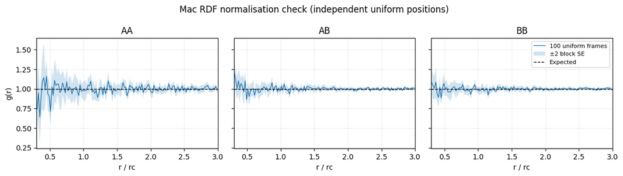

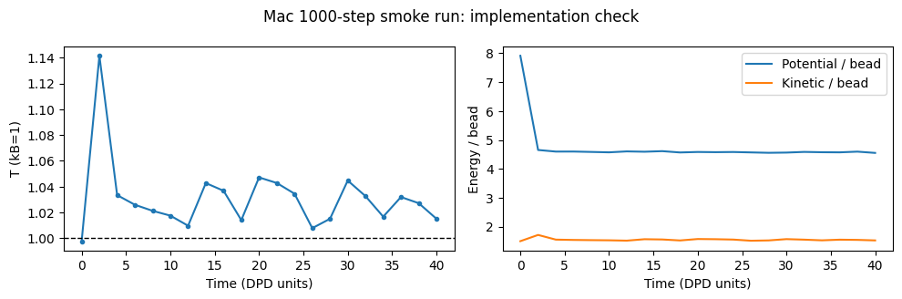

```
Final smoke temperature: 1.01504; all saved values finite.
The short trace does not establish equilibration or timestep accuracy; B1–B3 remain to do.
Mac integrated g_AA, 0.5 <= r < 3: 1.000976535
Mac integrated g_AB, 0.5 <= r < 3: 0.999822139
Mac integrated g_BB, 0.5 <= r < 3: 0.999230453
```

```python
rdf = np.genfromtxt("data/a_uniform_rdf_blocks.csv", delimiter=",", names=True)
fig, axes = plt.subplots(1, 3, figsize=(12, 3.4), sharey=True)
for ax, pair in zip(axes, ("AA", "AB", "BB")):
    blocks = np.array([rdf["g_" + pair][rdf["block"] == b]
                       for b in np.unique(rdf["block"])])
    r = rdf["r"][rdf["block"] == 0]
    mean = blocks.mean(axis=0)
    sem = blocks.std(axis=0, ddof=1) / np.sqrt(len(blocks))
    keep = r >= 0.3
    ax.plot(r[keep], mean[keep], lw=1, label="100 uniform frames")
    ax.fill_between(r[keep], (mean-2*sem)[keep], (mean+2*sem)[keep],
                    alpha=.2, label="±2 block SE")
    ax.axhline(1, color="black", ls="--", lw=1, label="Expected")
    ax.set(title=pair, xlabel="r / rc", xlim=(.3, 3))
    ax.grid(alpha=.2)
axes[0].set_ylabel("g(r)")
axes[-1].legend(fontsize=8)
fig.suptitle("Mac RDF normalisation check (independent uniform positions)")
fig.tight_layout()
plt.show()

thermo = np.genfromtxt("data/a_smoke_thermo.csv", delimiter=",", names=True)
assert all(np.isfinite(thermo[name]).all() for name in thermo.dtype.names)
fig, axes = plt.subplots(1, 2, figsize=(10, 3.3))
axes[0].plot(thermo["time"], thermo["T"], marker=".")
axes[0].axhline(1, color="black", ls="--", lw=1)
axes[0].set(xlabel="Time (DPD units)", ylabel="T (kB=1)")
axes[1].plot(thermo["time"], thermo["Epot"]/3000, label="Potential / bead")
axes[1].plot(thermo["time"], thermo["Ekin"]/3000, label="Kinetic / bead")
axes[1].set(xlabel="Time (DPD units)", ylabel="Energy / bead")
axes[1].legend()
fig.suptitle("Mac 1000-step smoke run: implementation check")
fig.tight_layout()
plt.show()
print(f"Final smoke temperature: {thermo['T'][-1]:.5f}; all saved values finite.")
print("The short trace does not establish equilibration or timestep accuracy; B1–B3 remain to do.")

summary = np.genfromtxt("data/a_uniform_rdf.csv", delimiter=",", names=True)
keep = summary["r_lo"] >= 0.5
shell = (4*np.pi/3) * (summary["r_hi"][keep]**3 - summary["r_lo"][keep]**3)
for pair, count_pairs, expected in zip(("AA", "AB", "BB"),
                                      (150*149/2, 150*350, 350*349/2),
                                      (1.00097653, 0.999822139, 0.999230453)):
    integrated = summary["count_"+pair][keep].sum() / (100*count_pairs*shell.sum()/1000)
    assert np.isclose(integrated, expected, rtol=0, atol=1e-8)
    print(f"Mac integrated g_{pair}, 0.5 <= r < 3: {integrated:.9f}")
```

## Part B: Verification for monomers (N = 1)

*In the oral you should be able to:* say which bug classes each of these three tests isolates, and why together they cover the code; derive the conservative pair potential; explain why the energy-conservation run needs a smaller timestep than a thermostatted run.

These three tests are designed to be run with parts of the physics switched off, which is what makes them sharp: each isolates one layer of the implementation. All three use the cubic box of side 10 with 3000 monomers and $a=25$ (see the run plan).

### B1) Energy conservation

Derive the potential energy expression belonging to the conservative pair force. Disable the dissipative and random interactions and verify conservation of total energy.

Start these runs from an equilibrated state: the restart file written at the end of the thermostatted monomer-fluid run, as you used restart files in A2. Your initial positions are random, and their overlaps release so much potential energy that a run without the thermostat heats itself to well above $kBT=1$: still a test of energy conservation, but not of the state you simulate everywhere else.

Deliver:

- the derivation of $UC(r)$ from $𝐅C$, and its value at $r=0$;
- a **figure** of total, kinetic and potential energy against time for the conservative-only run;
- a **table** of the relative energy drift for at least three time steps ($Δt$ = 0.04, 0.02, 0.01, 0.005 are suggested), each run to the same physical time, with the observed scaling stated. Do not be alarmed if the largest time step does not conserve energy at all: say what you see, and explain why this run needs a smaller $Δt$ than your thermostatted production runs do.

### B1 — Energy conservation

The conservative pair force is $FC(r)=a(1−r/rc)$ for $r<rc$. Using $FC=−dUC/dr$ and choosing $UC(rc)=0$ gives

$$UC(r)={arc2(1−r/rc)2,r<rc,0,r≥rc.$$

Therefore, $UC(0)=12.5$ for $a=25$ and $rc=1$.

Dissipative and random forces were disabled, while conservative forces remained enabled. All runs started from the same equilibrated thermostatted-fluid restart and reached the same physical time, $t=200$. This avoids the strong initial heating associated with randomly placed, overlapping particles.

The energy figure shows kinetic, potential and total energy for $Δt=0.01$. Kinetic and potential energy fluctuate through energy exchange, while their sum remains approximately constant. Relative drift was calculated as $ϵ(t)=[E(t)−E(0)]/|E(0)|$.

[output not shown]

A smaller timestep is needed here because numerical energy errors accumulate without a thermostat. In thermostatted runs, dissipative forces can remove numerical heating, so a stable temperature alone does not establish accurate integration. This test checks the conservative force–potential relation, neighbour-list implementation and integration accuracy.

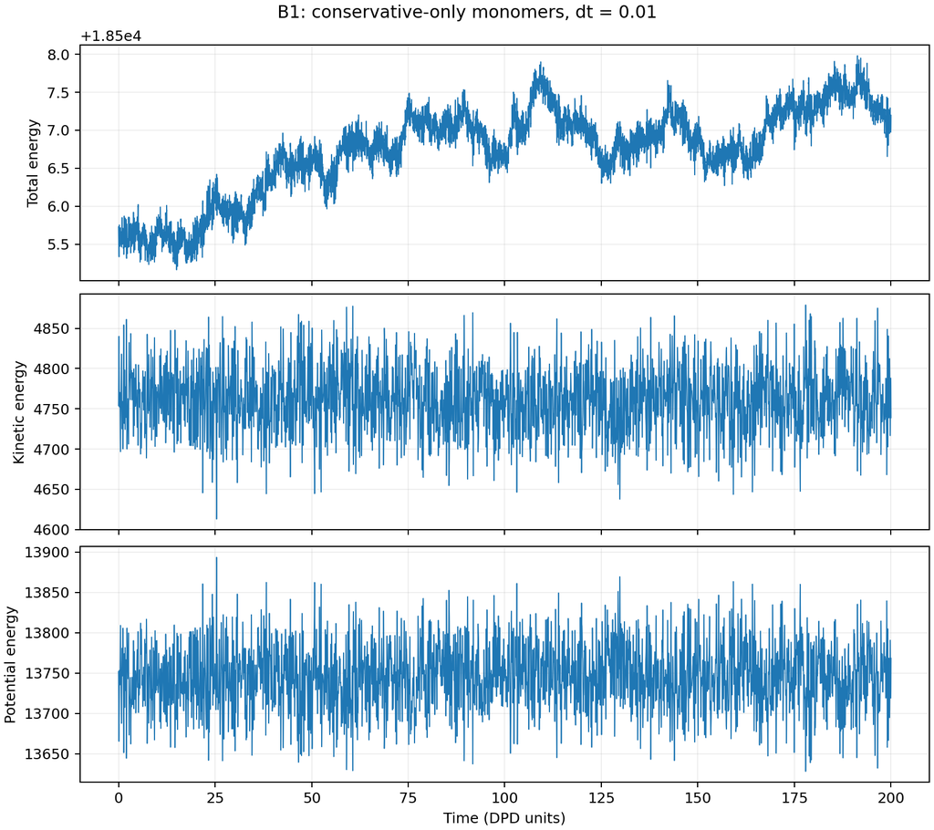

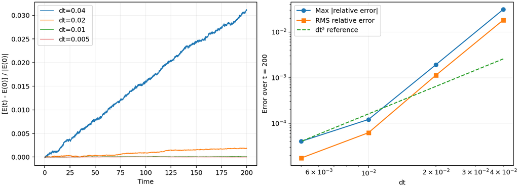

### B2) Ideal-gas structure

Disable the conservative interactions, keeping the dissipative and random forces on. The beads then interact only through friction and noise, so their equilibrium structure must be that of an ideal gas.

Deliver a **figure** of $g(r)$ for this run, showing it is flat and equal to 1 within the noise, and a sentence on what a *non*-flat result would have told you (this test catches both a broken $g(r)$ normalisation and a conservative force that is not really off).

### B3) Velocity statistics

Verify that the velocity distribution matches the imposed temperature (Maxwellian, with the correct variance), independent of the conservative interactions.

Deliver:

- a **figure** of the velocity histogram with the Maxwell-Boltzmann prediction on top, for a run with the conservative force on and one with it off;
- a **table** of the measured $kBT$ from the variance in both cases, next to the imposed value, and a sentence comparing the deviation you find with what Groot and Warren report for the Verlet scheme with $λ=1/2$ at $Δt=0.04$ (Fig. 1 and the text beside it);
- a short statement of what this verifies about your $σ$ and $γ$: if you had used a wrong fluctuation-dissipation relation, what would this table look like?

### B2 — Ideal-gas structure

Conservative forces were disabled while dissipative and random forces remained enabled. With no conservative potential, equilibrium positions should be uniformly distributed, giving $g(r)=1$. The particles still interact dynamically through friction and noise.

The AA, AB and BB RDFs were calculated using exact shell volumes and finite-system pair counts. After discarding 5000 equilibration steps, 300 frames were sampled and divided into 15 blocks for uncertainty estimates.

The RDF figure is approximately flat at one for all pair types. Shell-volume-weighted averages over $0.3≤r≤3$ are 0.999757 (AA), 0.999927 (AB) and 0.999990 (BB), with block standard errors of 0.000134, 0.000163 and 0.000190, respectively. Small-distance bins are noisier because their shell volumes contain fewer pairs.

A systematic non-flat result would suggest incorrect RDF counting/normalization or conservative interactions that were not fully disabled. This test therefore checks both the RDF implementation and the conservative-force switch.

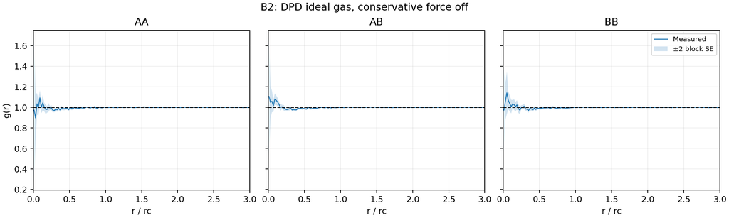

### B3 — Velocity statistics

Completed-step velocities were sampled with conservative forces both enabled and disabled, while keeping the DPD thermostat active. At equilibrium, each Cartesian velocity component should follow

$$p(vα)=m2πkBTexp(−mvα22kBT),Var(vα)=kBTm.$$

The speed $s=|v|$ instead follows the Maxwell distribution,

$$p(s)=4πs2(m2πkBT)3/2exp(−ms22kBT).$$

The figure compares normalized component and speed histograms with predictions using both the imposed temperature and the measured temperature. Both conservative-force settings produce approximately Maxwellian distributions, although their widths are slightly larger than predicted at the imposed temperature.

Temperature was calculated from unbinned component variances:

$$kBTvar=m3[Var(vx)+Var(vy)+Var(vz)].$$

[output not shown]

Groot and Warren report approximately 2% heating for Verlet with $λ=1/2$ at $Δt=0.04$. Our few-percent deviations are qualitatively consistent with this finite-timestep bias, although their reference density is 4 rather than our 3.

These results support the thermostat implementation and show approximately Maxwellian velocity statistics in both conservative systems. They also reveal finite-step temperature error. The required fluctuation–dissipation conditions are $σ2=2γkBT$ and $wD=wR2$. With correct weights but incorrect amplitudes, both systems would tend towards the wrong temperature, $kBTeffective=σ2/(2γ)$, and their histogram widths would disagree with the imposed prediction.

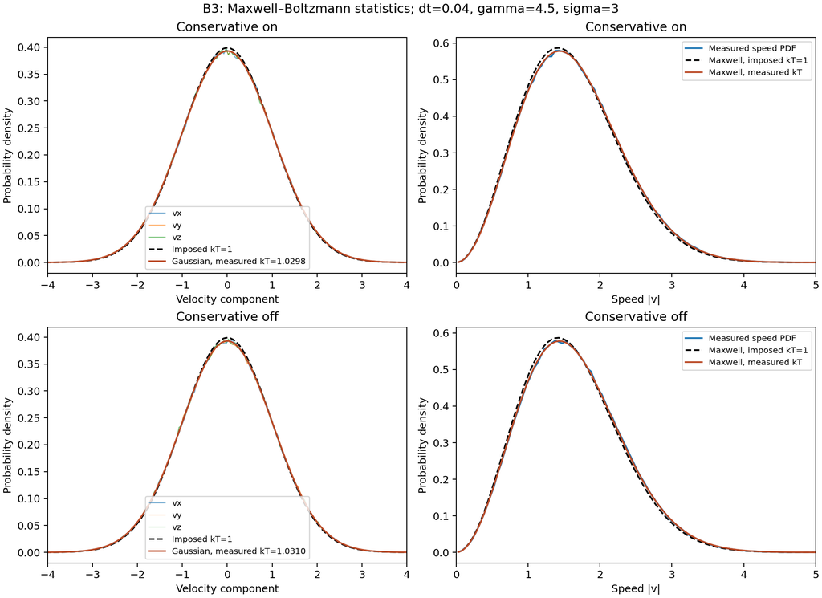

```python
# B2/B3: flat g(r); velocity histogram against Maxwell-Boltzmann
```

## Part C: Validation for monomers (N = 1)

*In the oral you should be able to:* say what agreement with a published simulation result does and does not validate; explain how χ is measured from composition profiles and what must be true of the profiles first; explain the sign, magnitude and factor of two of your surface tension.

**Every demixing run** (C2, C3, C4, and Part D) uses the same geometry. The box is $20×10×10$, elongated along $x$, with 6000 beads, and starts with A in the half $x<10$ and B in the half $x>10$. The two phases then form two flat slabs with **two flat interfaces perpendicular to $x$**, and the two bulk regions are wide enough to read a composition from. In a cubic box the system can separate along any axis, or not into flat slabs at all, and then neither the composition profile nor the surface tension means anything. Groot and Warren elongate their box along $z$; we use $x$ throughout, so read their $z$ as our $x$.

The **composition profile** is the number density of A and of B in thin slabs perpendicular to $x$ (a bin width of about 0.2 to 0.5), averaged over the run after equilibration, and the A fraction $ϕA(x)=ρA/(ρA+ρB)$ computed from them. Write it out in blocks during the run (every few thousand steps), not only once at the end: C2 asks when the profile became steady, and the error estimates of C3 come from the scatter between blocks.

### C1) Radial distribution function

Reproduce the $g(r)$ of Fig. 2 ($ρ=3$, $a=25$).

Deliver a **figure** with your $g(r)$ and the published curve on the same axes (digitise a few points from the figure if you have no data file), and a sentence on where they agree and where they do not. State your run length and how you know $g(r)$ has converged.

### C1 — Radial distribution function

The monomer fluid was simulated at $ρ=3$, $aAA=aAB=aBB=25$ and imposed $kBT=1$, with conservative and DPD thermostat forces enabled. The run used 120,000 steps at $Δt=0.04$, corresponding to a total time of 4800. The first 20,000 steps were discarded, leaving 100,000 production steps, 2000 sampled configurations and 20 blocks.

The RDF figure overlays the all-pair simulation RDF with the digitized curve from Groot and Warren’s Fig. 2. Agreement is good over the supplied reference range, approximately $0.17≤r/rc≤0.99$. The RMSE is 0.00595. The largest signed difference is −0.01176 at $r/rc=0.67145$, where the simulation lies slightly below the reference. These small differences may include digitization, finite-size and numerical effects; they should not be attributed entirely to sampling noise.

The RDF has the expected liquid structure: close pairs are strongly suppressed by soft repulsion, a first-neighbour peak occurs near $r/rc≈0.85$, and weak oscillations decay towards $g(r)=1$. The finite DPD potential makes overlap energetically costly without imposing a strict hard core. Structural correlations can extend beyond the interaction cutoff.

Convergence was assessed by comparing the first and second production halves. Their curves nearly overlap, with an RMS difference of 0.00127. Estimated standard errors remain of comparable magnitude when the block length increases from 5000 to 10,000 and 20,000 steps, without a clear systematic increase. This supports a stationary, well-sampled RDF, although the largest block size leaves only five blocks and therefore a noisier uncertainty estimate.

The required deliverables are the simulation/reference RDF overlay, the agreement assessment, the stated run length and the convergence evidence. The RDF and convergence figures provide these. Agreement supports the equilibrium pair structure at this state; it does not independently validate transport properties or demixing.

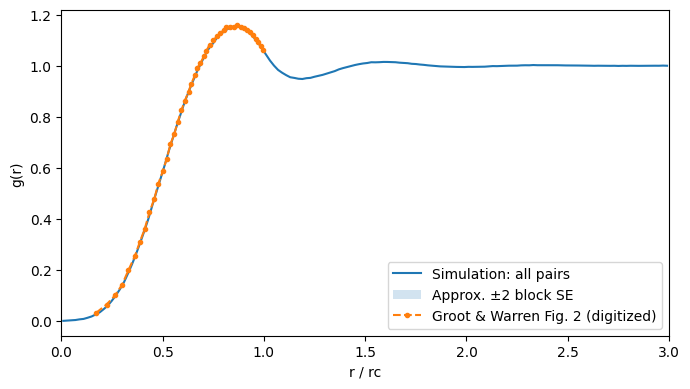

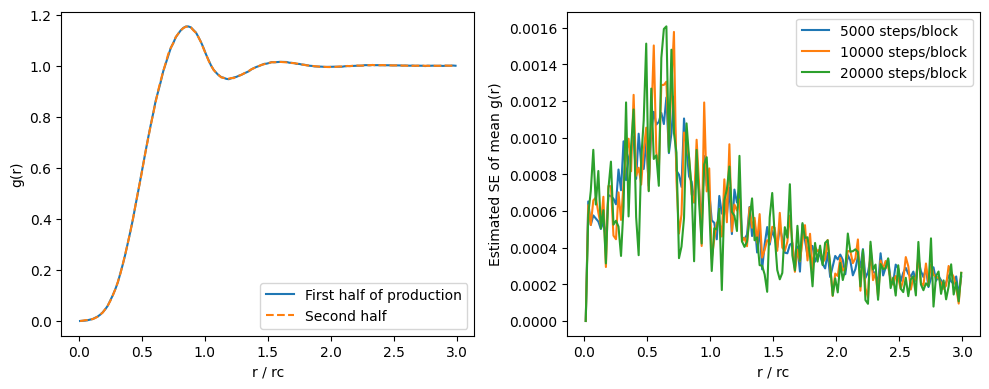

```
{'total_steps': 120000,
 'discard_steps': 20000,
 'production_steps': 100000,
 'total_time': 4800.0,
 'production_frames': 2000,
 'blocks': 20,
 'reference_RMSE_over_digitized_range': 0.005948588848262324,
 'largest_reference_difference_r': 0.6714507097246712,
 'largest_reference_difference': -0.011758750974929177,
 'first_vs_second_half_RMS_difference': 0.0012678623874690543}
```

```
Assess convergence from overlapping first/second-half curves and stable SE on reblocking.
Describe agreement over the digitized range only (the supplied reference ends near r=1).
Agreement validates this equilibrium structure at these conditions; it does not validate every force, transport property, or timestep.
```

```python
from pathlib import Path
import json
import numpy as np
import matplotlib.pyplot as plt
try:
    from IPython.display import display
except ImportError:
    display = print
ROOT = Path.cwd()                 # folder containing A3.ipynb, code/, data/
TAG = 'c1'
REFERENCE = ROOT /  'data/reference/Groot_fig2_fitteddaata.csv'
m = json.loads((ROOT / f'data/{TAG}_manifest.json').read_text())
rdf = np.atleast_1d(np.genfromtxt(ROOT / f'data/{TAG}_rdf.csv', delimiter=',', names=True))
b = np.atleast_1d(np.genfromtxt(ROOT / f'data/{TAG}_rdf_blocks.csv', delimiter=',', names=True))
ids = np.unique(b['block'])
N = m['num_part']; NA = N // 2; NB = N - NA
weights = np.array([NA*(NA-1), 2*NA*NB, NB*(NB-1)]) / (N*(N-1))
def pooled(rows):
    return np.column_stack([rows['g_AA'], rows['g_AB'], rows['g_BB']]) @ weights
r = rdf['r']; blocks = np.array([pooled(b[b['block']==i]) for i in ids])
frames = np.array([b[b['block']==i]['frames'][0] for i in ids])
assert len(ids)>=8 and np.all(frames==frames[0]), 'Use at least 8 equal production blocks.'
g = pooled(rdf)
assert np.allclose(g, blocks.mean(axis=0), atol=1e-8)
se = blocks.std(axis=0, ddof=1)/np.sqrt(len(ids))
ref = np.loadtxt(REFERENCE, delimiter=',')  # no header; columns r, g(r)
ref = ref[np.argsort(ref[:,0])]
interp = np.interp(ref[:,0], r, g)
mask = (ref[:,0]>=r.min()) & (ref[:,0]<=r.max())
rmse = float(np.sqrt(np.mean((interp[mask]-ref[mask,1])**2)))
worst = int(np.flatnonzero(mask)[np.argmax(np.abs(interp[mask]-ref[mask,1]))])
half = len(ids)//2
first, last = blocks[:half].mean(axis=0), blocks[half:].mean(axis=0)
fig, ax = plt.subplots(figsize=(7,4))
ax.plot(r,g,label='Simulation: all pairs');ax.fill_between(r,g-2*se,g+2*se,alpha=.2,label='Approx. ±2 block SE')
ax.plot(ref[:,0],ref[:,1],'o--',ms=3,label='Groot & Warren Fig. 2 (digitized)')
ax.set(xlabel='r / rc',ylabel='g(r)',xlim=(0,3));ax.legend();fig.tight_layout()
fig.savefig(ROOT/'data/C1_RDF.png',dpi=200);plt.show()
fig, axes = plt.subplots(1,2,figsize=(10,4))
axes[0].plot(r,first,label='First half of production');axes[0].plot(r,last,'--',label='Second half')
axes[0].set(xlabel='r / rc',ylabel='g(r)');axes[0].legend()
for q in [1,2,4]:
    nb=len(ids)//q
    if nb>=4:
        merged=blocks[:nb*q].reshape(nb,q,len(r)).mean(axis=1)
        axes[1].plot(r,merged.std(axis=0,ddof=1)/np.sqrt(nb),label=f'{q*m["block"]} steps/block')
axes[1].set(xlabel='r / rc',ylabel='Estimated SE of mean g(r)');axes[1].legend()
fig.tight_layout();fig.savefig(ROOT/'data/C1_convergence.png',dpi=200);plt.show()
summary={'total_steps':m['steps'],'discard_steps':m['equil'],'production_steps':m['steps']-m['equil'],
         'total_time':m['steps']*m['dt'],'production_frames':int(rdf['frames'][0]),'blocks':len(ids),
         'reference_RMSE_over_digitized_range':rmse,'largest_reference_difference_r':float(ref[worst,0]),
         'largest_reference_difference':float(interp[worst]-ref[worst,1]),
         'first_vs_second_half_RMS_difference':float(np.sqrt(np.mean((first-last)**2)))}
(ROOT/'data/C1_summary.json').write_text(json.dumps(summary,indent=2));display(summary)
print('Assess convergence from overlapping first/second-half curves and stable SE on reblocking.')
print('Describe agreement over the digitized range only (the supplied reference ends near r=1).')
print('Agreement validates this equilibrium structure at these conditions; it does not validate every force, transport property, or timestep.')
```

### C2) Binary demixing

Reproduce the phase separation of Fig. 6, using the parameters in its caption ($aAB=37$) and the geometry above.

Deliver:

- a **snapshot** of the demixed system (OVITO, beads coloured by type);
- a **figure** of the composition profile along $x$, showing the two bulk plateaus and the two interfaces;
- a statement of how long the run needed to reach a steady profile, and how you decided it had.

### C2 — Binary demixing

The binary monomer system was simulated with $aAA=aBB=25$ and $aAB=37$, at $ρ=3$ and imposed $kBT=1$. The elongated periodic box was $20×10×10$, containing 6000 beads. A and B initially occupied opposite halves along $x$. Conservative and DPD thermostat forces remained enabled.

The stronger repulsion between unlike particles favours demixing by reducing AB contacts. The OVITO snapshot shows two compositionally distinct slabs, consistent with the density and composition profiles. Each phase retains a small minority population because thermal mixing competes with segregation.

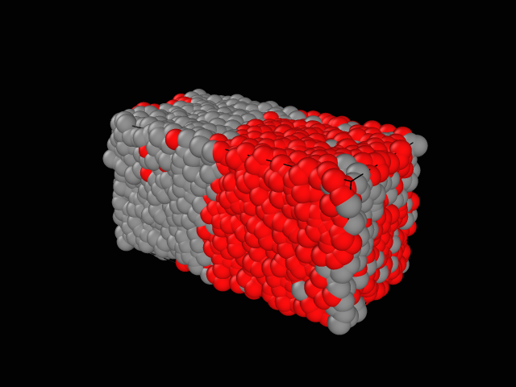

The density figure reproduces the main features of Groot and Warren’s Fig. 6: two nearly homogeneous bulk plateaus, smooth interfacial transitions and a small dip in the total density near each interface. The A, B and total-density curves agree closely with the digitized reference after a small periodic translation of 0.02494 length units. This translation accounts for the arbitrary position of the interfaces.

The minority A fraction in the B-rich bulk is 0.04058, while the minority B fraction in the A-rich bulk is 0.04071. Their close agreement is consistent with the symmetry of the interaction parameters. The corresponding majority fractions are approximately 0.9594 and 0.9593.

There are two interfaces: one near $x=10$ and another across the periodic $x=0/20$ boundary. The two boundary edges represent the same periodic interface.

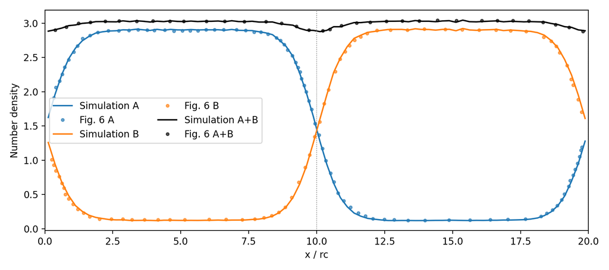

The simulation ran for 120,000 steps at $Δt=0.04$, reaching $t=4800$. Data before $t=800$ (20,000 steps) were discarded, leaving 100,000 production steps.

The rolling-profile diagnostic identifies a candidate steady time of $t=600$, corresponding to 15,000 steps. The profile history shows persistent bulk regions and interfaces, and the aligned and laboratory-frame averages have similar plateau values, with small differences near the interfaces.

However, the minority-fraction histories show substantial fluctuations and a tendency towards larger values late in the run. Thus, $t=600$ indicates approximate stability of the overall profile rather than definitive convergence of the precise bulk compositions. Comparing production-half means with block uncertainties is needed to distinguish slow relaxation from correlated fluctuations.

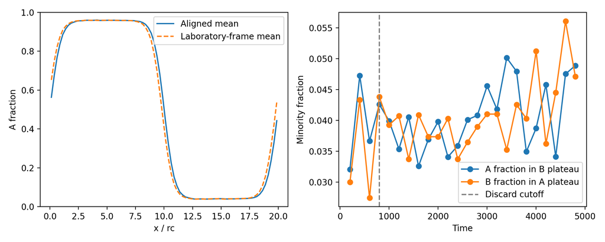

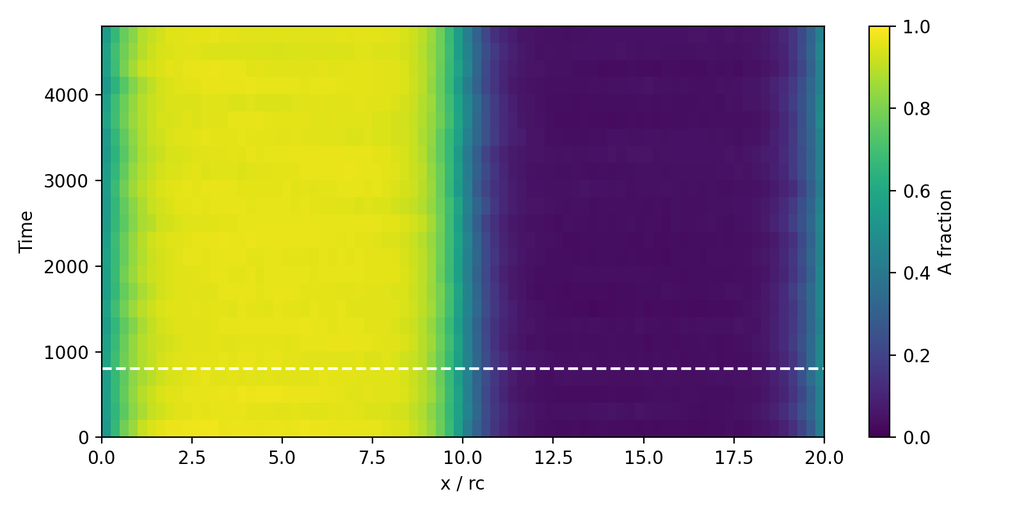

The OVITO snapshot, density/composition figures and time-history diagnostics provide the requested snapshot, two-phase profile and assessment of the time needed to approach a steady profile. The results support successful reproduction of the qualitative phase separation in Fig. 6, with the convergence qualification above.

```
Cutoff t=800; 20 retained blocks; first/second-half bulk difference=0.005945; combined SE=0.00253
Candidate steady time (rolling-profile RMS <0.03 relative to final 3 blocks): 600.0
```

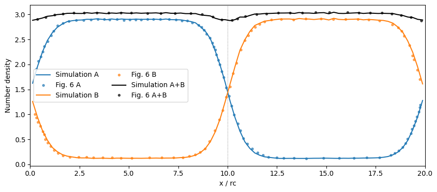

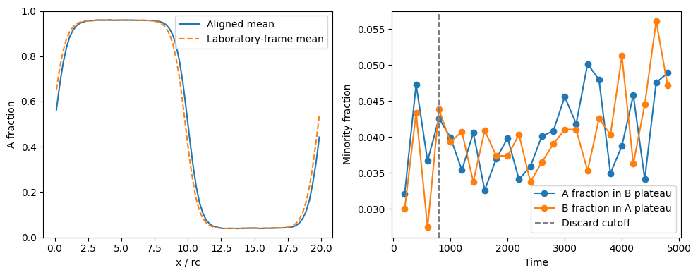

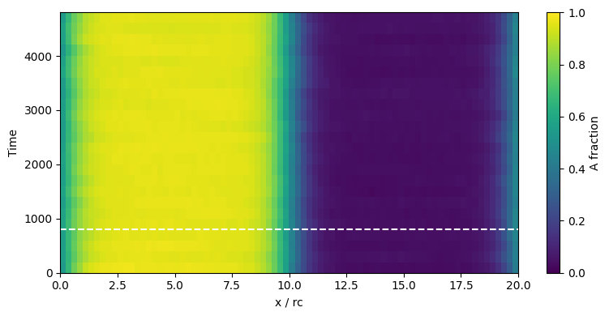

```
{'total_steps': 120000,
 'total_time': 4800.0,
 'discard_time': 800.0,
 'candidate_steady_time': 600.0,
 'reference_translation': 0.024937655860348684,
 'minority_A_in_B': 0.04057983149033847,
 'minority_B_in_A': 0.04071275536385034}
```

```
Two interfaces: one near x=Lx/2, the other at the periodic x=0/Lx boundary.
Confirm persistent flat plateaus and stable blocks before declaring equilibrium. The threshold is only a diagnostic.
For your OVITO snapshot open data/c2.pdb: visualization labels C=A, O=B; use the final equilibrated frame.
```

```python
from pathlib import Path
import json
import numpy as np
import matplotlib.pyplot as plt
try:
    from IPython.display import display
except ImportError:
    display = print
ROOT = Path.cwd()
def csv(name):
    return np.atleast_1d(np.genfromtxt(ROOT/name,delimiter=',',names=True,dtype=None,encoding='utf-8'))

def sem_reblock(values):
    """Report SE versus block size; retain the largest supported estimate."""
    v=np.asarray(values,float)
    if len(v)<4: raise ValueError('Need at least four production blocks; run longer.')
    out=[]
    for q in [1,2,4]:
        nb=len(v)//q
        if nb>=4:
            z=v[:nb*q].reshape(nb,q).mean(axis=1)
            out.append((q,nb,float(z.std(ddof=1)/np.sqrt(nb))))
    return max(z[2] for z in out),out

def profiles(tag,discard_time=None):
    m=json.loads((ROOT/f'data/{tag}_manifest.json').read_text())
    raw=csv(f'data/{tag}_profile_blocks.csv');ids=np.unique(raw['block'])
    groups=[raw[raw['block']==i] for i in ids]
    assert len({len(g) for g in groups})==1
    assert np.all([np.allclose(g['x'],groups[0]['x']) for g in groups])
    assert len({int(g['frames'][0]) for g in groups})==1, 'Use equal full blocks.'
    x=groups[0]['x'];ra=np.array([g['rho_A'] for g in groups]);rb=np.array([g['rho_B'] for g in groups])
    la=np.array([g['rho_A_lab'] for g in groups]);lb=np.array([g['rho_B_lab'] for g in groups])
    start=np.array([g['t_start'][0] for g in groups]);end=np.array([g['t_end'][0] for g in groups])
    cut=m['equil']*m['dt'] if discard_time is None else discard_time
    keep=start>=cut-1e-9
    L=m['L'][0];windowA=(x>=.2*L)&(x<.3*L);windowB=(x>=.7*L)&(x<.8*L)
    phi=ra/(ra+rb)
    minorityAinB=ra[:,windowB].sum(axis=1)/(ra[:,windowB]+rb[:,windowB]).sum(axis=1)
    minorityBinA=rb[:,windowA].sum(axis=1)/(ra[:,windowA]+rb[:,windowA]).sum(axis=1)
    # Conservation: density integrals must recover NA=NB=N/2 per block.
    dx=m['L'][0]/len(x);area=m['L'][1]*m['L'][2]
    assert np.allclose(ra.sum(axis=1)*dx*area,m['num_part']/2)
    assert np.allclose(rb.sum(axis=1)*dx*area,m['num_part']/2)
    return dict(m=m,x=x,ra=ra,rb=rb,la=la,lb=lb,phi=phi,start=start,end=end,keep=keep,cut=cut,
                bphi=minorityAinB,aphi=minorityBinA,order=np.array([g['order'][0] for g in groups]),
                aligned=np.array([g['aligned_fraction'][0] for g in groups]),windowA=windowA,windowB=windowB)

def steady_candidate(d):
    """Exploratory tolerance diagnostic, not a proof of stationarity."""
    z=d['phi'];window=3
    if len(z)<2*window:return None
    target=z[-window:].mean(axis=0)
    dist=np.array([np.sqrt(np.mean((z[i-window+1:i+1].mean(axis=0)-target)**2))
                   for i in range(window-1,len(z))])
    for j in range(len(dist)-window+1):
        if np.all(dist[j:]<.03):return float(d['end'][j+window-1])
    return None

def diagnose(d):
    keep=d['keep']; n=int(keep.sum())
    if n<4:raise ValueError('Too few retained blocks after the chosen discard time.')
    if np.any(d['aligned'][keep]<.95) and d['m']['aab']>25:
        print('CAUTION: some frames lack a strong x slab; inspect morphology before extracting bulk chi.')
    vals=d['bphi'][keep];half=n//2
    e1,_=sem_reblock(vals[:half]) if half>=4 else (float('nan'),[])
    e2,_=sem_reblock(vals[half:]) if n-half>=4 else (float('nan'),[])
    drift=abs(vals[:half].mean()-vals[half:].mean())
    print(f'Cutoff t={d["cut"]:g}; {n} retained blocks; first/second-half bulk difference={drift:.4g}; combined SE={np.hypot(e1,e2):.4g}')
    print('Candidate steady time (rolling-profile RMS <0.03 relative to final 3 blocks):',steady_candidate(d))
    return drift,float(np.hypot(e1,e2))
# %% C2 settings: rerun with a later cutoff if convergence diagnostics require it.
TAG='c2'
DISCARD_TIME=None  # None uses the C run's equilibration setting; alternatively e.g. 1600.0
REFERENCE_SHIFT=None  # None finds a periodic translation for the digitized curves.
d=profiles(TAG,DISCARD_TIME);diagnose(d)
k=d['keep'];x=d['x'];L=d['m']['L'][0]
A=d['ra'][k].mean(axis=0);B=d['rb'][k].mean(axis=0)
refs={s:np.loadtxt(ROOT / f'data/reference/Groot_fig6_{s}.csv',delimiter=',') for s in ['A','B','AB']}
# AB is the total-density curve; verified from the supplied values near rho=3.
if REFERENCE_SHIFT is None:
    shifts=np.linspace(-L/2,L/2,401,endpoint=False)
    scores=[sum(np.mean((np.interp((refs[s][:,0]+shift)%L,x,v,period=L)-refs[s][:,1])**2)
                for s,v in [('A',A),('B',B)]) for shift in shifts]
    REFERENCE_SHIFT=float(shifts[np.argmin(scores)])
fig,ax=plt.subplots(figsize=(9,4))
for s,v,color in [('A',A,'tab:blue'),('B',B,'tab:orange'),('AB',A+B,'black')]:
    ax.plot(x,v,color=color,label='Simulation '+('A+B' if s=='AB' else s))
    xx=(refs[s][:,0]+REFERENCE_SHIFT)%L;idx=np.argsort(xx)
    ax.plot(xx[idx],refs[s][idx,1],'.',color=color,alpha=.65,label='Fig. 6 '+('A+B' if s=='AB' else s))
for v in [0,L/2,L]:ax.axvline(v,color='grey',ls=':',lw=.8)
ax.set(xlabel='x / rc',ylabel='Number density',xlim=(0,L));ax.legend(ncol=2);fig.tight_layout()
fig.savefig(ROOT/'data/C2_density.png',dpi=200);plt.show()
fig,axes=plt.subplots(1,2,figsize=(10,4))
phi=d['phi'][k];axes[0].plot(x,A/(A+B),label='Aligned mean')
labA=d['la'][k].mean(axis=0);labB=d['lb'][k].mean(axis=0)
axes[0].plot(x,labA/(labA+labB),'--',label='Laboratory-frame mean')
axes[0].set(xlabel='x / rc',ylabel='A fraction',ylim=(0,1));axes[0].legend()
axes[1].plot(d['end'],d['bphi'],'o-',label='A fraction in B plateau')
axes[1].plot(d['end'],d['aphi'],'o-',label='B fraction in A plateau')
axes[1].axvline(d['cut'],color='grey',ls='--',label='Discard cutoff')
axes[1].set(xlabel='Time',ylabel='Minority fraction');axes[1].legend();fig.tight_layout()
fig.savefig(ROOT/'data/C2_composition_convergence.png',dpi=200);plt.show()
fig,ax=plt.subplots(figsize=(8,4));im=ax.imshow(d['phi'],origin='lower',aspect='auto',extent=[0,L,0,d['end'][-1]],vmin=0,vmax=1)
fig.colorbar(im,ax=ax,label='A fraction');ax.axhline(d['cut'],color='white',ls='--');ax.set(xlabel='x / rc',ylabel='Time')
fig.tight_layout();fig.savefig(ROOT/'data/C2_profile_history.png',dpi=200);plt.show()
se=phi.std(axis=0,ddof=1)/np.sqrt(k.sum())
np.savetxt(ROOT/'data/C2_profile_table.csv',np.column_stack([x,A,B,A/(A+B),se]),delimiter=',',header='x,rho_A,rho_B,phi_A,phi_block_SE',comments='')
summary={'total_steps':d['m']['steps'],'total_time':d['m']['steps']*d['m']['dt'],
         'discard_time':d['cut'],'candidate_steady_time':steady_candidate(d),'reference_translation':REFERENCE_SHIFT,
         'minority_A_in_B':float(d['bphi'][k].mean()),'minority_B_in_A':float(d['aphi'][k].mean())}
(ROOT/'data/C2_summary.json').write_text(json.dumps(summary,indent=2));display(summary)
print('Two interfaces: one near x=Lx/2, the other at the periodic x=0/Lx boundary.')
print('Confirm persistent flat plateaus and stable blocks before declaring equilibrium. The threshold is only a diagnostic.')
print('For your OVITO snapshot open data/c2.pdb: visualization labels C=A, O=B; use the final equilibrated frame.')
```

### C3) Measuring the χ-parameter

Measure χ with Eq. (18) from the composition profiles of demixed runs at $ρ=3$, for this edition's series

$$aAB∈{35, 39, 43, 47},aAA=aBB=25.$$

For monomers $NA=1$, and $ϕA$ in Eq. (18) is the A fraction in the bulk of the B-rich phase. Read it from the plateau of the profile, away from both interfaces.

Deliver:

- a **figure** with the four composition profiles;
- a **table** of the bulk compositions and the resulting χ per $aAB$, each with an error estimate;
- a **figure** of χ against $Δa=aAB−aAA$ with a linear fit, the fitted slope stated, and the slope of Eq. (24) (Fig. 7) for comparison. Groot and Warren fit only the points with $χ>3$ (p. 4429), with the same integrator and $Δt$ as yours: compare like with like, and report the fit over all four points as well.

Then state what must be true of the profiles before Eq. (18) may be applied at all, and confirm that it is true of yours.

### C3 — Measuring the χ-parameter

Four monomer mixtures were simulated at $ρ=3$, with $aAA=aBB=25$ and $aAB=35,39,43,47$. Each run used the elongated $20×10×10$ periodic box, initially separated A/B slabs, and the Verlet scheme with $λ=1/2$ and $Δt=0.04$.

Each simulation reached $t=4800$. Samples before $t=800$ were discarded, leaving 20 production blocks. The minority A fraction was measured in the B-rich bulk plateau, using the registered window $14≤x<16$, away from both interfaces.

For monomers, Eq. (18) gives

$$χ=ln[(1−ϕA)/ϕA]1−2ϕA.$$

Here $ϕA$ is the A fraction in the B-rich plateau, rather than the overall A fraction of 0.5. Composition standard errors were estimated using reblocking, and χ standard errors using a block jackknife.

| aAB | Delta a | A fraction in B | Composition SE | Chi | Chi SE |
| --- | --- | --- | --- | --- | --- |
| 35 | 10 | 0.100587 | 0.00353432 | 2.74242 | 0.0248733 |
| 39 | 14 | 0.021541 | 0.000973914 | 3.98782 | 0.0402293 |
| 43 | 18 | 0.00566255 | 0.000563703 | 5.22740 | 0.0990145 |
| 47 | 22 | 0.00256082 | 0.000321966 | 5.99557 | 0.124277 |

Increasing AB repulsion produces stronger segregation: the minority concentration decreases, the interfaces narrow, and χ increases. This is expected because unlike contacts become increasingly costly. The relative uncertainty in the minority concentration becomes larger at stronger segregation, where fewer minority particles are available for sampling.

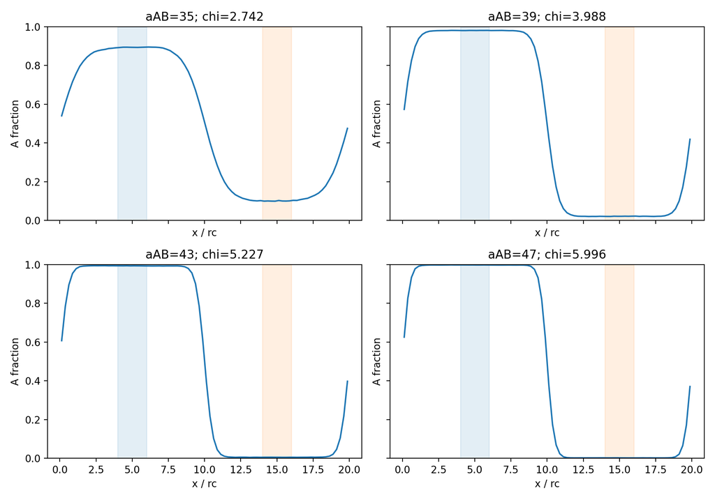

Eq. (18) requires steady two-phase coexistence and homogeneous bulk plateaus sufficiently far from the interfaces. These conditions are supported by the visible plateaus and bulk-composition histories. The rolling-profile diagnostic gives a candidate steady time of $t=600$ for each case, before the discard cutoff.

The first/second-half bulk-composition differences are approximately 1.55, 0.81, 1.71 and 0.36 combined standard errors for increasing $aAB$. None exceeds two combined standard errors, supporting consistency between the production halves. This does not prove that all slow correlations have disappeared; block-size and bulk-window sensitivity checks remain relevant.

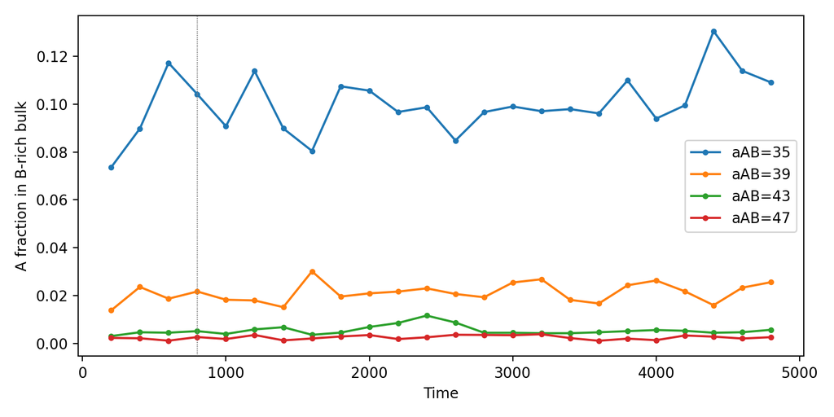

Weighted fits through the origin were performed for $χ$ against $Δa=aAB−25$:

- All four points: slope $0.2793±0.0017$.
- Only points with measured $χ>3$: slope $0.2838±0.0023$.
- Groot and Warren, Eq. (24): slope $0.286±0.002$.

The all-point slope is approximately 2.3% below the published value and differs by about 2.6 combined standard errors. The restricted fit agrees within the combined uncertainty. This is the appropriate comparison with the paper, which fitted only $χ>3$: the $aAB=35$ point, with $χ=2.74242$, is excluded from that fit.

The results support an approximately linear mapping between excess repulsion and χ. Including the weaker-segregation point changes the fitted slope, showing why the fitting range must be stated. The reported sampling errors do not include every possible finite-size, plateau-selection or model-mapping effect.

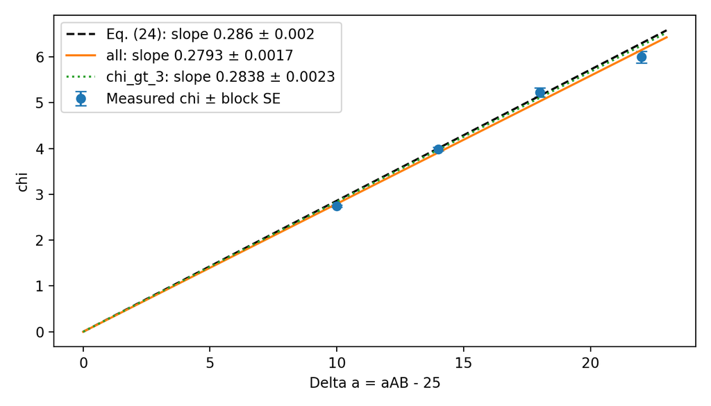

```
Cutoff t=800; 20 retained blocks; first/second-half bulk difference=0.008215; combined SE=0.0053
Candidate steady time (rolling-profile RMS <0.03 relative to final 3 blocks): 600.0
Cutoff t=800; 20 retained blocks; first/second-half bulk difference=0.001777; combined SE=0.002183
Candidate steady time (rolling-profile RMS <0.03 relative to final 3 blocks): 600.0
Cutoff t=800; 20 retained blocks; first/second-half bulk difference=0.001649; combined SE=0.0009628
Candidate steady time (rolling-profile RMS <0.03 relative to final 3 blocks): 600.0
```

```
Cutoff t=800; 20 retained blocks; first/second-half bulk difference=0.0001868; combined SE=0.0005171
Candidate steady time (rolling-profile RMS <0.03 relative to final 3 blocks): 600.0
```

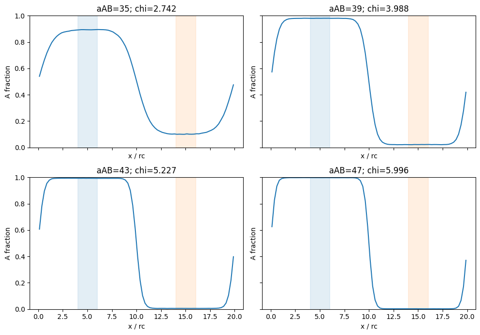

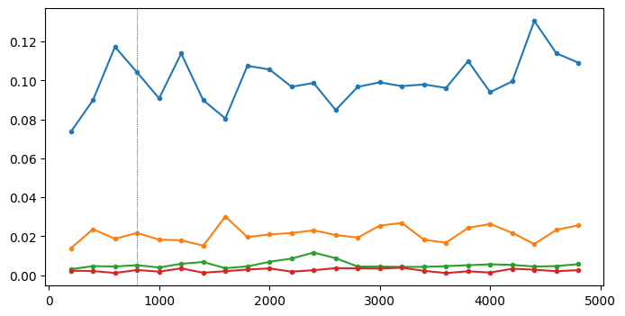

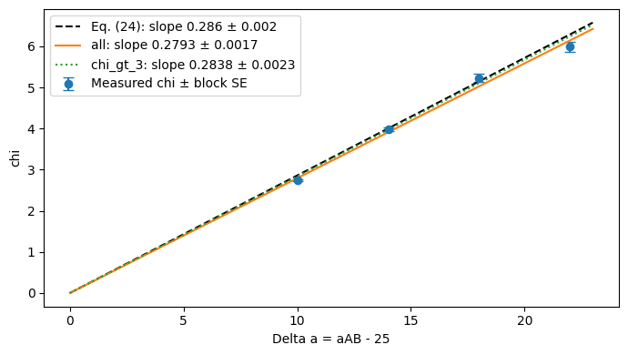

```
array([(35., 10., 0.1005872 , 0.00353432, 2.74242224, 0.0248733 , 0.10648036, 0.10257944, -1.99223589e-03, 6.43318530e-04, 800., 20.),
       (39., 14., 0.02154105, 0.00097391, 3.98782222, 0.0402293 , 0.01965041, 0.02149138,  4.96639176e-05, 3.01237993e-04, 800., 20.),
       (43., 18., 0.00566255, 0.0005637 , 5.2274035 , 0.09901445, 0.00648304, 0.00560873,  5.38134616e-05, 8.65767925e-05, 800., 20.),
       (47., 22., 0.00256082, 0.00032197, 5.99556996, 0.12427722, 0.00203134, 0.00256365, -2.82881256e-06, 9.19905267e-05, 800., 20.)],
      dtype=[('aAB', '<f8'), ('delta_a', '<f8'), ('phi_A_in_B', '<f8'), ('phi_SE', '<f8'), ('chi', '<f8'), ('chi_SE', '<f8'), ('phi_B_in_A', '<f8'), ('phi_wider_window', '<f8'), ('window_difference', '<f8'), ('window_difference_SE', '<f8'), ('discard_time', '<f8'), ('blocks', '<f8')])
```

```
array([('all', 'through_origin', 0.27932561, 0.00169729,  0.        , 0.        , 4, 13.3756909 ),
       ('all', 'free_intercept', 0.29405633, 0.00728219, -0.18213874, 0.0875612 , 4,  9.04874663),
       ('chi_gt_3', 'through_origin', 0.28375516, 0.00232186,  0.        , 0.        , 3,  5.55939365),
       ('chi_gt_3', 'free_intercept', 0.2654455 , 0.01461291,  0.28514163, 0.22468006, 3,  3.94877693)],
      dtype=[('subset', '<U8'), ('fit', '<U14'), ('slope', '<f8'), ('slope_SE', '<f8'), ('intercept', '<f8'), ('intercept_SE', '<f8'), ('n', '<i8'), ('weighted_residual_sum', '<f8')])
```

```
Check C3_profiles, C3_bulk_convergence and C3_reblocking before reporting final chi values.
Eq. (18) requires equilibrated coexisting phases, homogeneous bulk plateaus, symmetry, and monomers.
The first point may have chi<3; report it but compare the chi>3 fit to the paper separately.
Fit SE uses supplied sampling errors; residuals, finite-size bias and model departures are separate uncertainties.
```

```python
from pathlib import Path
import json
import numpy as np
import matplotlib.pyplot as plt
try:
    from IPython.display import display
except ImportError:
    display = print
ROOT = Path.cwd()
def csv(name):
    return np.atleast_1d(np.genfromtxt(ROOT/name,delimiter=',',names=True,dtype=None,encoding='utf-8'))

def sem_reblock(values):
    """Report SE versus block size; retain the largest supported estimate."""
    v=np.asarray(values,float)
    if len(v)<4: raise ValueError('Need at least four production blocks; run longer.')
    out=[]
    for q in [1,2,4]:
        nb=len(v)//q
        if nb>=4:
            z=v[:nb*q].reshape(nb,q).mean(axis=1)
            out.append((q,nb,float(z.std(ddof=1)/np.sqrt(nb))))
    return max(z[2] for z in out),out

def profiles(tag,discard_time=None):
    m=json.loads((ROOT/f'data/{tag}_manifest.json').read_text())
    raw=csv(f'data/{tag}_profile_blocks.csv');ids=np.unique(raw['block'])
    groups=[raw[raw['block']==i] for i in ids]
    assert len({len(g) for g in groups})==1
    assert np.all([np.allclose(g['x'],groups[0]['x']) for g in groups])
    assert len({int(g['frames'][0]) for g in groups})==1, 'Use equal full blocks.'
    x=groups[0]['x'];ra=np.array([g['rho_A'] for g in groups]);rb=np.array([g['rho_B'] for g in groups])
    la=np.array([g['rho_A_lab'] for g in groups]);lb=np.array([g['rho_B_lab'] for g in groups])
    start=np.array([g['t_start'][0] for g in groups]);end=np.array([g['t_end'][0] for g in groups])
    cut=m['equil']*m['dt'] if discard_time is None else discard_time
    keep=start>=cut-1e-9
    L=m['L'][0];windowA=(x>=.2*L)&(x<.3*L);windowB=(x>=.7*L)&(x<.8*L)
    phi=ra/(ra+rb)
    minorityAinB=ra[:,windowB].sum(axis=1)/(ra[:,windowB]+rb[:,windowB]).sum(axis=1)
    minorityBinA=rb[:,windowA].sum(axis=1)/(ra[:,windowA]+rb[:,windowA]).sum(axis=1)
    # Conservation: density integrals must recover NA=NB=N/2 per block.
    dx=m['L'][0]/len(x);area=m['L'][1]*m['L'][2]
    assert np.allclose(ra.sum(axis=1)*dx*area,m['num_part']/2)
    assert np.allclose(rb.sum(axis=1)*dx*area,m['num_part']/2)
    return dict(m=m,x=x,ra=ra,rb=rb,la=la,lb=lb,phi=phi,start=start,end=end,keep=keep,cut=cut,
                bphi=minorityAinB,aphi=minorityBinA,order=np.array([g['order'][0] for g in groups]),
                aligned=np.array([g['aligned_fraction'][0] for g in groups]),windowA=windowA,windowB=windowB)

def steady_candidate(d):
    """Exploratory tolerance diagnostic, not a proof of stationarity."""
    z=d['phi'];window=3
    if len(z)<2*window:return None
    target=z[-window:].mean(axis=0)
    dist=np.array([np.sqrt(np.mean((z[i-window+1:i+1].mean(axis=0)-target)**2))
                   for i in range(window-1,len(z))])
    for j in range(len(dist)-window+1):
        if np.all(dist[j:]<.03):return float(d['end'][j+window-1])
    return None

def diagnose(d):
    keep=d['keep']; n=int(keep.sum())
    if n<4:raise ValueError('Too few retained blocks after the chosen discard time.')
    if np.any(d['aligned'][keep]<.95) and d['m']['aab']>25:
        print('CAUTION: some frames lack a strong x slab; inspect morphology before extracting bulk chi.')
    vals=d['bphi'][keep];half=n//2
    e1,_=sem_reblock(vals[:half]) if half>=4 else (float('nan'),[])
    e2,_=sem_reblock(vals[half:]) if n-half>=4 else (float('nan'),[])
    drift=abs(vals[:half].mean()-vals[half:].mean())
    print(f'Cutoff t={d["cut"]:g}; {n} retained blocks; first/second-half bulk difference={drift:.4g}; combined SE={np.hypot(e1,e2):.4g}')
    print('Candidate steady time (rolling-profile RMS <0.03 relative to final 3 blocks):',steady_candidate(d))
    return drift,float(np.hypot(e1,e2))
# %% C3 configuration and measurements.
AAB=[35,39,43,47]
# Each cutoff is a physical time; None uses C_EQUIL * dt from that run.
DISCARD_TIME={a:None for a in AAB}
rows=[];reblocks=[]
fig,axes=plt.subplots(2,2,figsize=(10,7),sharex=True,sharey=True)
figc,axc=plt.subplots(figsize=(8,4))
for a,ax in zip(AAB,axes.flat):
    d=profiles(f'c3_a{a}',DISCARD_TIME[a]);drift,driftSE=diagnose(d)
    keep=d['keep'];v=d['bphi'][keep];phi=float(v.mean())
    if not 0<phi<.5:raise ValueError(f'aAB={a}: no valid minority plateau; inspect demixing/convergence.')
    if np.any(v<=0):raise ValueError(f'aAB={a}: zero minority counts in a block. Run longer; do not add arbitrary pseudocounts.')
    def chi(p):return np.log((1-p)/p)/(1-2*p)
    value=float(chi(phi));phiSE,rbs=sem_reblock(v)
    # Jackknife after combining successive blocks, retaining the largest SE.
    chi_errors=[]
    for q,nb,se0 in rbs:
        z=v[:nb*q].reshape(nb,q).mean(axis=1)
        loo=(z.sum()-z)/(nb-1);est=chi(loo)
        err=float(np.sqrt((nb-1)/nb*np.sum((est-est.mean())**2)))
        chi_errors.append(err);reblocks.append([a,q,nb,q*d['m']['block']*d['m']['dt'],se0,err])
    chiSE=max(chi_errors)
    # A-phase symmetry and a wider-window sensitivity check.
    sym=float(d['aphi'][keep].mean())
    wide=(d['x']>=.65*d['m']['L'][0])&(d['x']<.85*d['m']['L'][0])
    widev=d['ra'][keep][:,wide].sum(axis=1)/(d['ra'][keep][:,wide]+d['rb'][keep][:,wide]).sum(axis=1)
    delta=v-widev;deltaSE,_=sem_reblock(delta)
    candidate=steady_candidate(d)
    if np.isfinite(driftSE) and drift>3*driftSE:print('WARNING: bulk composition still changes between production halves.')
    if abs(delta.mean())>max(3*deltaSE,.1*phi):print('WARNING: bulk-window sensitivity; inspect plateau width/flatness.')
    if candidate is not None and candidate>d['cut']:print('WARNING: candidate steady time is later than discard cutoff; reassess retained blocks.')
    rows.append([a,a-25,phi,phiSE,value,chiSE,sym,float(widev.mean()),float(delta.mean()),deltaSE,d['cut'],int(keep.sum())])
    meanA=d['ra'][keep].mean(axis=0);meanB=d['rb'][keep].mean(axis=0)
    ax.plot(d['x'],meanA/(meanA+meanB),label=f'aAB={a}')
    ax.axvspan(.2*d['m']['L'][0],.3*d['m']['L'][0],alpha=.12,color='tab:blue')
    ax.axvspan(.7*d['m']['L'][0],.8*d['m']['L'][0],alpha=.12,color='tab:orange')
    ax.set(title=f'aAB={a}; chi={value:.3f}',xlabel='x / rc',ylabel='A fraction',ylim=(0,1))
    axc.plot(d['end'],d['bphi'],'o-',ms=3,label=f'aAB={a}');axc.axvline(d['cut'],color='grey',ls=':',lw=.5)
fig.tight_layout();fig.savefig(ROOT/'data/C3_profiles.png',dpi=200);plt.show()
axc.set(xlabel='Time',ylabel='A fraction in B-rich bulk');axc.legend();figc.tight_layout()
figc.savefig(ROOT/'data/C3_bulk_convergence.png',dpi=200);plt.show()
rows=np.array(rows)
header='aAB,delta_a,phi_A_in_B,phi_SE,chi,chi_SE,phi_B_in_A,phi_wider_window,window_difference,window_difference_SE,discard_time,blocks'
np.savetxt(ROOT/'data/C3_chi_table.csv',rows,delimiter=',',header=header,comments='')
np.savetxt(ROOT/'data/C3_reblocking.csv',reblocks,delimiter=',',header='aAB,merge_factor,blocks,block_time,phi_SE,chi_jackknife_SE',comments='')
# Weighted fits: the origin-constrained fit directly compares Eq. (24).
x=rows[:,1];y=rows[:,4];err=rows[:,5]
if np.any(err<=0):raise ValueError('Zero estimated chi error: sampling is inadequate.')
fits=[]
fig,ax=plt.subplots(figsize=(7,4));ax.errorbar(x,y,yerr=err,fmt='o',capsize=4,label='Measured chi ± block SE')
xx=np.linspace(0,x.max()+1,200);ax.plot(xx,.286*xx,'k--',label='Eq. (24): slope 0.286 ± 0.002')
for label,mask,style in [('all',np.ones(len(x),bool),'-'),('chi_gt_3',y>3,':')]:
    if mask.sum()<2:
        print(f'Not enough points for {label} fit.');continue
    X=x[mask];Y=y[mask];w=1/err[mask]**2
    slope=float(np.sum(w*X*Y)/np.sum(w*X*X));slopeSE=float(1/np.sqrt(np.sum(w*X*X)))
    fitres=float(np.sum(w*(Y-slope*X)**2));fits.append([label,'through_origin',slope,slopeSE,0.,0.,int(mask.sum()),fitres])
    ax.plot(xx,slope*xx,style,label=f'{label}: slope {slope:.4f} ± {slopeSE:.4f}')
    # Free-intercept fit as a sensitivity diagnostic, not a forced physical offset.
    design=np.column_stack([X,np.ones(len(X))]);cov=np.linalg.inv(design.T@(w[:,None]*design))
    beta=cov@(design.T@(w*Y));fits.append([label,'free_intercept',float(beta[0]),float(np.sqrt(cov[0,0])),float(beta[1]),float(np.sqrt(cov[1,1])),int(mask.sum()),float(np.sum(w*(Y-design@beta)**2))])
ax.set(xlabel='Delta a = aAB - 25',ylabel='chi');ax.legend();fig.tight_layout()
fig.savefig(ROOT/'data/C3_chi_fit.png',dpi=200);plt.show()
with (ROOT/'data/C3_fit_table.csv').open('w') as f:
    f.write('subset,fit,slope,slope_SE,intercept,intercept_SE,n,weighted_residual_sum\n')
    for z in fits:f.write(','.join(map(str,z))+'\n')
display(csv('data/C3_chi_table.csv'));display(csv('data/C3_fit_table.csv'))
print('Check C3_profiles, C3_bulk_convergence and C3_reblocking before reporting final chi values.')
print('Eq. (18) requires equilibrated coexisting phases, homogeneous bulk plateaus, symmetry, and monomers.')
print('The first point may have chi<3; report it but compare the chi>3 fit to the paper separately.')
print('Fit SE uses supplied sampling errors; residuals, finite-size bias and model departures are separate uncertainties.')
```

### C4) Surface tension *(new this edition)*

For the same demixed runs as C3, obtain the interfacial tension from Eq. (31). With the interface normal along $x$ it reads

$$σs=∫[pxx(x)−12(pyy(x)+pzz(x))]dx,$$

the normal minus the tangential pressure, integrated across the interface. You do **not** need the pressure as a function of $x$. What you need is this:

1. **The diagonal of the pressure tensor of the whole box**, at every sampling step: $Pαα=1V[∑imviα2+∑i<jrij,αFij,α]$, $α=x,y,z$, with $𝐅ij$ the conservative and spring forces, as in Eq. (15). Your A2 code accumulates only the scalar virial $∑𝐫ij·𝐅ij$; accumulate its three components separately, in the same place.
2. **The step from Eq. (31) to those three numbers.** Take the integral over the whole periodic box. Derive $σs$ in terms of $Lx$ and the box averages $Pxx$, $Pyy$, $Pzz$, say where the **two** interfaces in the box enter, and explain why the bulk regions add nothing to the integral.
3. **A time average with an honest error.** Successive samples are strongly correlated, so the naive standard error of the mean is too small; use block averages.
4. **A control run** at $aAB=25$, with the same separated start: one phase, no interface, so $σs$ must vanish within its error. That checks your tensor for a bias between $x$ and the other two directions; a wrong overall factor would pass it, so check the magnitude too, against Groot and Warren's monomer surface tension, Eq. (36).

Deliver:

- a **table** and a **figure** of $σs$ against $Δa$, with error bars, including the control;
- your derivation of item 2;
- a discussion of three things: the **sign** of $σs$ and why it must be that sign for a stable interface; the **trend** with $Δa$; and the **limit** as $Δa$ approaches the mixing point, where the two phases become identical.

### C4 — Interfacial tension

Interfacial tension was measured for the four demixed C3 systems and an additional control with $aAB=25$. All runs used 6000 monomers in the periodic $20×10×10$ box, initially separated A/B slabs, $aAA=aBB=25$, and $Δt=0.04$. Measurements before $t=800$ were discarded, leaving 20 production blocks per case.

The diagonal pressure tensor was calculated from the instantaneous kinetic contribution and conservative/spring pair virials:

$$Pαα=1V[∑imiviα2+∑i<jrij,αFij,αC+spring].$$

Dissipative and random forces were excluded from this virial measurement. The spring contribution is zero for these monomers.

For interfaces normal to $x$, define

$$q(x)=pxx(x)−pyy(x)+pzz(x)2.$$

Integrating over the whole periodic box gives

$$∫0Lxq(x)dx=Lx[Pxx−Pyy+Pzz2].$$

The bulk phases are isotropic, so their contributions vanish on average. The box contains two equivalent interfaces, each contributing $σs$. Therefore,

$$σs=Lx2⟨Pxx−Pyy+Pzz2⟩.$$

The factor of two accounts for the two periodic interfaces. Tension is reported in reduced units of energy per area.

| aAB | Delta a | Surface tension | Block SE | Eq. (36), measured chi | Eq. (36), mapped chi |
| --- | --- | --- | --- | --- | --- |
| 25 | 0 | 0.00368 | 0.02158 | — | — |
| 35 | 10 | 0.22308 | 0.02230 | 0.15230 | 0.21614 |
| 39 | 14 | 0.87950 | 0.02299 | 0.84078 | 0.84907 |
| 43 | 18 | 1.39909 | 0.02447 | 1.40521 | 1.37306 |
| 47 | 22 | 1.76544 | 0.01810 | 1.69251 | 1.79310 |

Successive pressure samples are correlated, so uncertainty was estimated from block averages rather than treating every sample as independent. Reblocking over durations of 200, 400 and 800 time units shows no sustained increase in the estimated standard error. The largest supported estimate was retained for each case. The largest duration leaves only five blocks, so its error estimate is less precise.

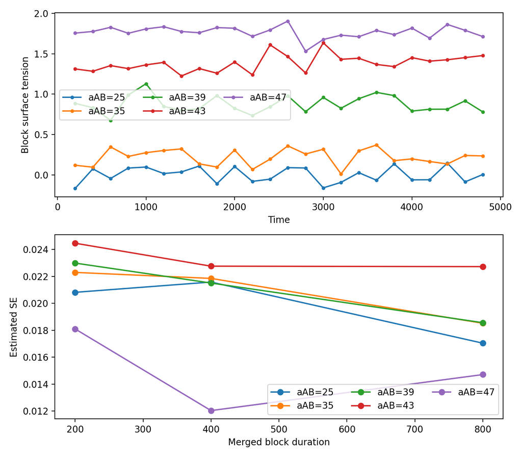

The control is consistent with zero: its mean is only approximately 0.17 standard errors from zero. Its composition nonuniformity, measured as the RMS deviation of the A fraction from 0.5, is 0.00196, supporting a well-mixed single phase. This checks for an artificial bias between the normal and tangential pressure components. It cannot detect an incorrect overall multiplicative factor, since multiplying zero still gives zero.

The magnitude was therefore also compared with Groot and Warren’s monomer relation, Eq. (36):

$$σs≃0.75ρkBTrcχ0.26(1−2.36χ)3/2,χ>2.36.$$

The figure evaluates this relation using both the measured C3 values of χ and the mapping $χ=0.286Δa$. The predicted and measured tensions have comparable magnitudes and reproduce the same increasing trend. Agreement is not exact: notably, the measured-χ prediction is lower at $aAB=35$ and 47. The displayed reference curves use central parameter values and do not include uncertainty from χ or the empirical fit, so tension-only error bars are insufficient for a complete significance comparison.

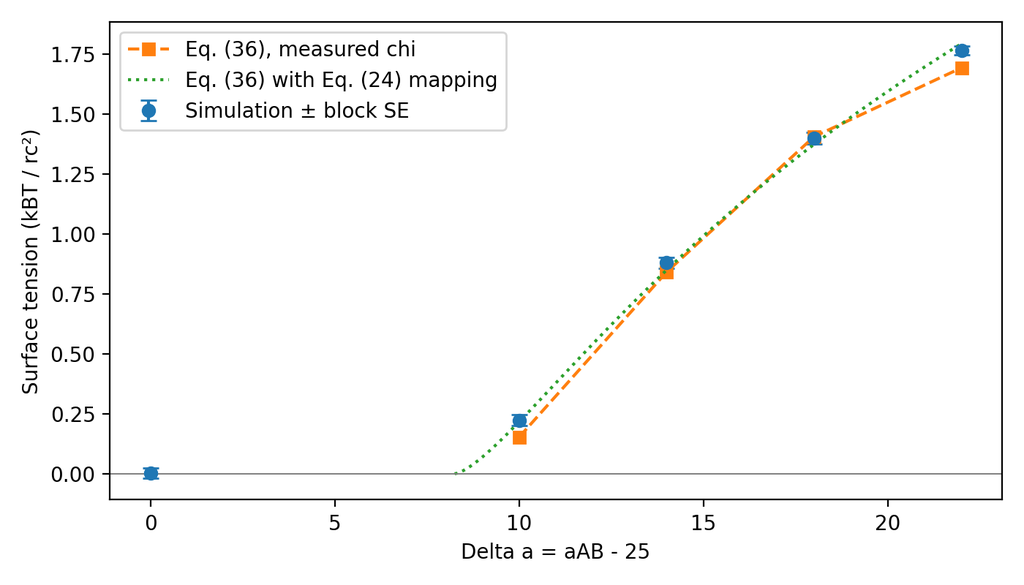

All demixed systems have positive tension, as expected for a stable interface with a positive free-energy cost per unit area. Increasing $Δa$ makes unlike contacts more costly and generally increases this interfacial cost. As the mixing critical point is approached, the two bulk phases become identical and the tension tends to zero. The empirical monomer fit uses $χcrit≈2.36$; the $aAB=25$ control is a fully mixed reference, not a measurement exactly at that critical point.

```
Control residual composition nonuniformity (RMS from 0.5): 0.0019609517066943873
```

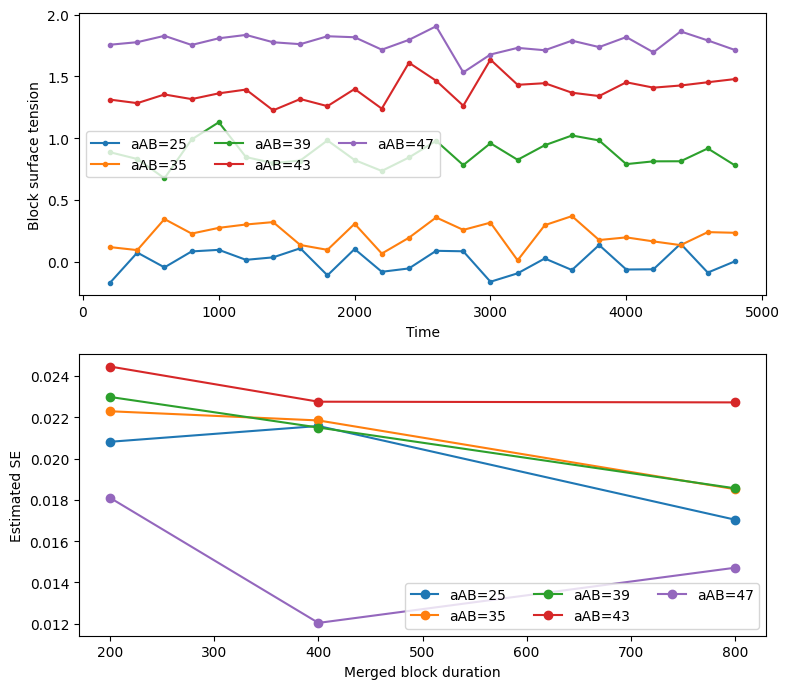

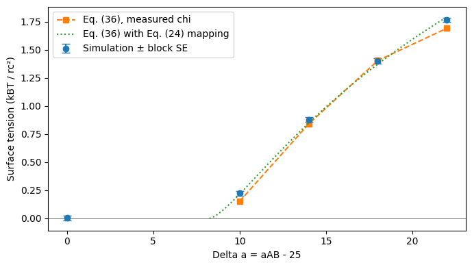

```
array([(25.,  0., 0.00367538, 0.02158346, 0.        , 0.        , 0.        , 0.        , 800., 20.),
       (35., 10., 0.22308073, 0.02229797, 2.74242224, 0.0248733 , 0.15230377, 0.21614423, 800., 20.),
       (39., 14., 0.87949603, 0.02299023, 3.98782222, 0.0402293 , 0.84077657, 0.84906823, 800., 20.),
       (43., 18., 1.39909307, 0.02446571, 5.2274035 , 0.09901445, 1.40520946, 1.37306117, 800., 20.),
       (47., 22., 1.76543799, 0.01809919, 5.99556996, 0.12427722, 1.69251096, 1.7931011 , 800., 20.)],
      dtype=[('aAB', '<f8'), ('delta_a', '<f8'), ('sigma', '<f8'), ('sigma_SE', '<f8'), ('chi', '<f8'), ('chi_SE', '<f8'), ('GW36_measured_chi', '<f8'), ('GW36_mapped_chi', '<f8'), ('discard_time', '<f8'), ('blocks', '<f8')])
```

```
Control compatible with zero within approx. 2 block SE: True
A stable demixed interface has positive tension; increasing Delta a generally increases tension.
Tension approaches zero at coexistence criticality, where phases become identical. The paper monomer fit uses chi_crit=2.36.
A failed control suggests bias or insufficient statistics. A passing control does not verify an overall factor: compare the magnitude to Eq. (36).
Inspect SE versus merged block duration. If it keeps increasing, extend the run/use larger blocks before interpreting error bars.
```

```python
from pathlib import Path
import json
import numpy as np
import matplotlib.pyplot as plt
try:
    from IPython.display import display
except ImportError:
    display = print
ROOT = Path.cwd()
def csv(name):
    return np.atleast_1d(np.genfromtxt(ROOT/name,delimiter=',',names=True,dtype=None,encoding='utf-8'))

def sem_reblock(values):
    """Report SE versus block size; retain the largest supported estimate."""
    v=np.asarray(values,float)
    if len(v)<4: raise ValueError('Need at least four production blocks; run longer.')
    out=[]
    for q in [1,2,4]:
        nb=len(v)//q
        if nb>=4:
            z=v[:nb*q].reshape(nb,q).mean(axis=1)
            out.append((q,nb,float(z.std(ddof=1)/np.sqrt(nb))))
    return max(z[2] for z in out),out

def profiles(tag,discard_time=None):
    m=json.loads((ROOT/f'data/{tag}_manifest.json').read_text())
    raw=csv(f'data/{tag}_profile_blocks.csv');ids=np.unique(raw['block'])
    groups=[raw[raw['block']==i] for i in ids]
    assert len({len(g) for g in groups})==1
    assert np.all([np.allclose(g['x'],groups[0]['x']) for g in groups])
    assert len({int(g['frames'][0]) for g in groups})==1, 'Use equal full blocks.'
    x=groups[0]['x'];ra=np.array([g['rho_A'] for g in groups]);rb=np.array([g['rho_B'] for g in groups])
    la=np.array([g['rho_A_lab'] for g in groups]);lb=np.array([g['rho_B_lab'] for g in groups])
    start=np.array([g['t_start'][0] for g in groups]);end=np.array([g['t_end'][0] for g in groups])
    cut=m['equil']*m['dt'] if discard_time is None else discard_time
    keep=start>=cut-1e-9
    L=m['L'][0];windowA=(x>=.2*L)&(x<.3*L);windowB=(x>=.7*L)&(x<.8*L)
    phi=ra/(ra+rb)
    minorityAinB=ra[:,windowB].sum(axis=1)/(ra[:,windowB]+rb[:,windowB]).sum(axis=1)
    minorityBinA=rb[:,windowA].sum(axis=1)/(ra[:,windowA]+rb[:,windowA]).sum(axis=1)
    # Conservation: density integrals must recover NA=NB=N/2 per block.
    dx=m['L'][0]/len(x);area=m['L'][1]*m['L'][2]
    assert np.allclose(ra.sum(axis=1)*dx*area,m['num_part']/2)
    assert np.allclose(rb.sum(axis=1)*dx*area,m['num_part']/2)
    return dict(m=m,x=x,ra=ra,rb=rb,la=la,lb=lb,phi=phi,start=start,end=end,keep=keep,cut=cut,
                bphi=minorityAinB,aphi=minorityBinA,order=np.array([g['order'][0] for g in groups]),
                aligned=np.array([g['aligned_fraction'][0] for g in groups]),windowA=windowA,windowB=windowB)

def steady_candidate(d):
    """Exploratory tolerance diagnostic, not a proof of stationarity."""
    z=d['phi'];window=3
    if len(z)<2*window:return None
    target=z[-window:].mean(axis=0)
    dist=np.array([np.sqrt(np.mean((z[i-window+1:i+1].mean(axis=0)-target)**2))
                   for i in range(window-1,len(z))])
    for j in range(len(dist)-window+1):
        if np.all(dist[j:]<.03):return float(d['end'][j+window-1])
    return None

def diagnose(d):
    keep=d['keep']; n=int(keep.sum())
    if n<4:raise ValueError('Too few retained blocks after the chosen discard time.')
    if np.any(d['aligned'][keep]<.95) and d['m']['aab']>25:
        print('CAUTION: some frames lack a strong x slab; inspect morphology before extracting bulk chi.')
    vals=d['bphi'][keep];half=n//2
    e1,_=sem_reblock(vals[:half]) if half>=4 else (float('nan'),[])
    e2,_=sem_reblock(vals[half:]) if n-half>=4 else (float('nan'),[])
    drift=abs(vals[:half].mean()-vals[half:].mean())
    print(f'Cutoff t={d["cut"]:g}; {n} retained blocks; first/second-half bulk difference={drift:.4g}; combined SE={np.hypot(e1,e2):.4g}')
    print('Candidate steady time (rolling-profile RMS <0.03 relative to final 3 blocks):',steady_candidate(d))
    return drift,float(np.hypot(e1,e2))
# %% C4 reuses the four C3 runs; run the C3 cell first to save its table.
chi_table=csv('data/C3_chi_table.csv')
CONTROL_DISCARD_TIME=None
rows=[];reblocks=[]
fig,axes=plt.subplots(2,1,figsize=(8,7))
for a in [25,35,39,43,47]:
    tag='c4_control' if a==25 else f'c3_a{a}'
    m=json.loads((ROOT/f'data/{tag}_manifest.json').read_text())
    block=csv(f'data/{tag}_pressure_blocks.csv')
    if a==25:
        cut=m['equil']*m['dt'] if CONTROL_DISCARD_TIME is None else CONTROL_DISCARD_TIME
        chi=0;chiSE=0
        control=profiles(tag,cut)
        phi_control=control['phi'][control['keep']].mean(axis=0)
        print('Control residual composition nonuniformity (RMS from 0.5):',float(np.sqrt(np.mean((phi_control-.5)**2))))
        if np.sqrt(np.mean((phi_control-.5)**2))>.05:print('WARNING: control labels have not fully mixed; inspect equilibration.')
    else:
        record=chi_table[np.isclose(chi_table['aAB'],a)][0]
        cut=float(record['discard_time']);chi=float(record['chi']);chiSE=float(record['chi_SE'])
    keep=block['t_start']>=cut-1e-9
    z=block['sigma_two_interfaces'][keep]
    assert np.all(block['frames'][keep]==block['frames'][keep][0])
    # Independent calculation verifies the saved factor of two.
    calc=.5*m['L'][0]*(block['Pxx']-.5*(block['Pyy']+block['Pzz']))
    assert np.allclose(calc,block['sigma_two_interfaces'],atol=1e-10)
    mean=float(z.mean());se,rb=sem_reblock(z)
    for q,nb,e in rb:reblocks.append([a,q,nb,q*m['block']*m['dt'],e])
    def gw36(c):return 0.75*3*1*1*c**.26*(1-2.36/c)**1.5 if c>2.36 else 0.
    theory=gw36(chi);mapped=gw36(.286*(a-25))
    rows.append([a,a-25,mean,se,chi,chiSE,theory,mapped,cut,len(z)])
    axes[0].plot(block['t_end'],block['sigma_two_interfaces'],'o-',ms=3,label=f'aAB={a}')
    axes[1].plot([v[0]*m['block']*m['dt'] for v in rb],[v[2] for v in rb],'o-',label=f'aAB={a}')
axes[0].set(xlabel='Time',ylabel='Block surface tension');axes[0].legend(ncol=3)
axes[1].set(xlabel='Merged block duration',ylabel='Estimated SE');axes[1].legend(ncol=3)
fig.tight_layout();fig.savefig(ROOT/'data/C4_convergence.png',dpi=200);plt.show()
rows=np.array(rows)
np.savetxt(ROOT/'data/C4_tension_table.csv',rows,delimiter=',',comments='',header='aAB,delta_a,sigma,sigma_SE,chi,chi_SE,GW36_measured_chi,GW36_mapped_chi,discard_time,blocks')
np.savetxt(ROOT/'data/C4_reblocking.csv',reblocks,delimiter=',',comments='',header='aAB,merge_factor,blocks,block_time,sigma_SE')
fig,ax=plt.subplots(figsize=(7,4))
ax.errorbar(rows[:,1],rows[:,2],yerr=rows[:,3],fmt='o',capsize=4,label='Simulation ± block SE')
ax.plot(rows[1:,1],rows[1:,6],'s--',label='Eq. (36), measured chi')
xx=np.linspace(2.36/.286+.001,rows[:,1].max(),200);cc=.286*xx
ax.plot(xx,.75*3*cc**.26*(1-2.36/cc)**1.5,':',label='Eq. (36) with Eq. (24) mapping')
ax.axhline(0,color='grey',lw=.7);ax.set(xlabel='Delta a = aAB - 25',ylabel='Surface tension (kBT / rc²)')
ax.legend();fig.tight_layout();fig.savefig(ROOT/'data/C4_surface_tension.png',dpi=200);plt.show()
display(csv('data/C4_tension_table.csv'))
print('Control compatible with zero within approx. 2 block SE:',bool(abs(rows[0,2])<=2*rows[0,3]))
print('A stable demixed interface has positive tension; increasing Delta a generally increases tension.')
print('Tension approaches zero at coexistence criticality, where phases become identical. The paper monomer fit uses chi_crit=2.36.')
print('A failed control suggests bias or insufficient statistics. A passing control does not verify an overall factor: compare the magnitude to Eq. (36).')
print('Inspect SE versus merged block duration. If it keeps increasing, extend the run/use larger blocks before interpreting error bars.')
```

## Part D: Validation for chains (N > 1)

*In the oral you should be able to:* explain why longer chains demix at smaller Δa, and what Eq. (27)'s χN means for a symmetric blend.

For chains of equal length $NA=NB=N$, Eq. (18) gives the product $χN$, with $ϕA$ the fraction of A **beads** in the B-rich phase. Demixing is governed by $χN$, so the values of $Δa$ that work for monomers are far too large for chains: at $Δa=16$ every chain length used here demixes completely, no A bead is left in the B-rich phase, $ϕA=0$ and Eq. (18) cannot be evaluated. That is why Part D uses much smaller $Δa$, and different values for each $N$ (see the run plan). Close to its critical point every interface is wide, and a chain is several bead diameters long: check, for each run, that the part of the profile you call bulk is really flat.

### D1) Snapshot

Provide a **snapshot** of equilibrated bead-spring chains with $N=5$ ($a=25$ for every pair, cubic box), and a **number** characterising the chains themselves: the mean-square end-to-end distance, compared with that of an ideal chain with the same springs (derive it: $N−1$ independent harmonic bonds with spring constant $C$). This is your check that the springs and the initialisation are doing what you think; say why the two numbers need not agree.

### D2) Two-phase simulations

Perform demixing simulations for chain lengths $N=3$, $5$ and $10$, all at $Δa=3$ ($aAB=28$).

Deliver a **figure** with the composition profiles of the three chain lengths on one set of axes, in the style of Fig. 6, so the effect of $N$ is visible in one figure, and a **snapshot** of each.

### D3) χ-parameter for chains

Measure χ for the chain systems, with a separate series of $Δa$ for each chain length:

| $N$ | $Δa$ |
| --- | --- |
| 3 | 3, 5, 7 |
| 5 | 2, 3.5, 5 |
| 10 | 1, 1.5, 2 |

($N=3$ at $Δa=3$ is the D2 run.)

Deliver a **table** of χ and $χN$ against $N$ and $Δa$, and a **figure** comparing your $χN/Δa$ with Eq. (27) and Fig. 8. Then answer the physical question: at fixed $Δa$, why do longer chains demix more readily? Argue it from your table, from $χN$ rather than from the pictures.

### D1 — Chain size and an equilibrium snapshot

We simulated 3000 beads at density 3 in a periodic $103$ box, with five beads per chain (600 chains), $aij=25$, $C=2$, and $Δt=0.04$. The run lasted 60,000 steps ($t=2400$). We discarded 10,000 steps ($t=400$), leaving 20 blocks of 2500 steps. The two bead types have identical interactions in this run. The snapshot below is an OVITO/OSPRay rendering of the final saved configuration at $t=2400$: A is blue and B is orange. Bonds connect consecutive beads using minimum-image periodic shifts; OVITO wraps bonds at the box boundaries. The displayed C/O file labels encode bead types, not chemical carbon/oxygen.

For an ideal chain, each bond vector $b$ has energy $Ub=C|b|2/2$. Its three independent Cartesian components have variance $kBT/C$, so $⟨b2⟩=3kBT/C$. With $N−1$ independent, zero-mean bond vectors,

$$⟨Re2⟩ideal=⟨|∑j=1N−1bj|2⟩=(N−1)3kBTC=6.00rc2(N=5, C=2, kBT=1).$$

The simulation gives **6.71495 ± 0.01319 $rc2$**, with block-reestimated standard error. Its mean squared bond length is **1.65076 $rc2$**, compared with 1.5 for isolated ideal springs. The first and second production-half means are **6.71300** and **6.71689**. The time history and reblocking plot below allow these values to be checked rather than assuming that a long run is equilibrated.

The ideal-chain value is a comparison, not an equality that the DPD fluid must satisfy. Bonded beads still repel, and other beads and correlations between successive bonds can change the chain size. The finite-step thermostat also has a small temperature bias, as found in B3. We use the imposed $kBT=1$ for the stated ideal reference and do not silently adjust it to fit the result.

We calculate each chain's end-to-end vector by summing its consecutive minimum-image bond vectors. Taking only the minimum-image distance between the two endpoints would give a wrong answer for an extended chain crossing the box. An independent periodic-boundary fixture tests this case.

The following analysis only reads saved data. It does not launch a simulation.

```
N | steps | discard_steps | blocks | Re2 | Re2_SE | ideal_Re2 | mean_bond2 | first_half | second_half
5 | 60000 | 10000 | 20 | 6.71495 | 0.013191 | 6 | 1.65076 | 6.713 | 6.71689
```

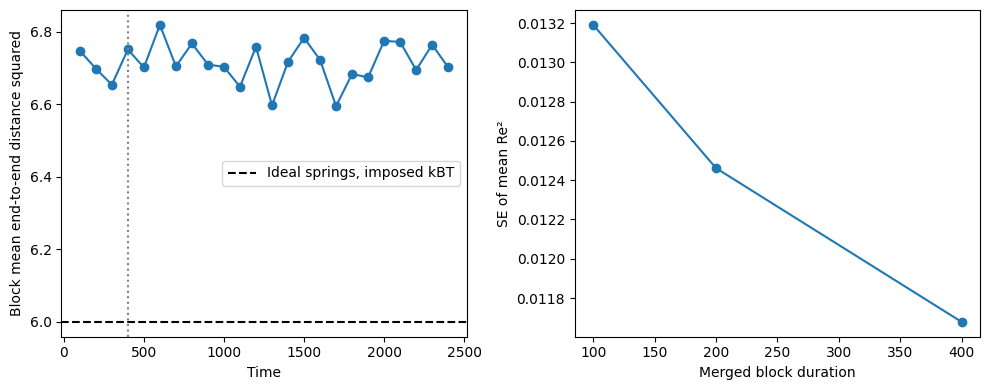

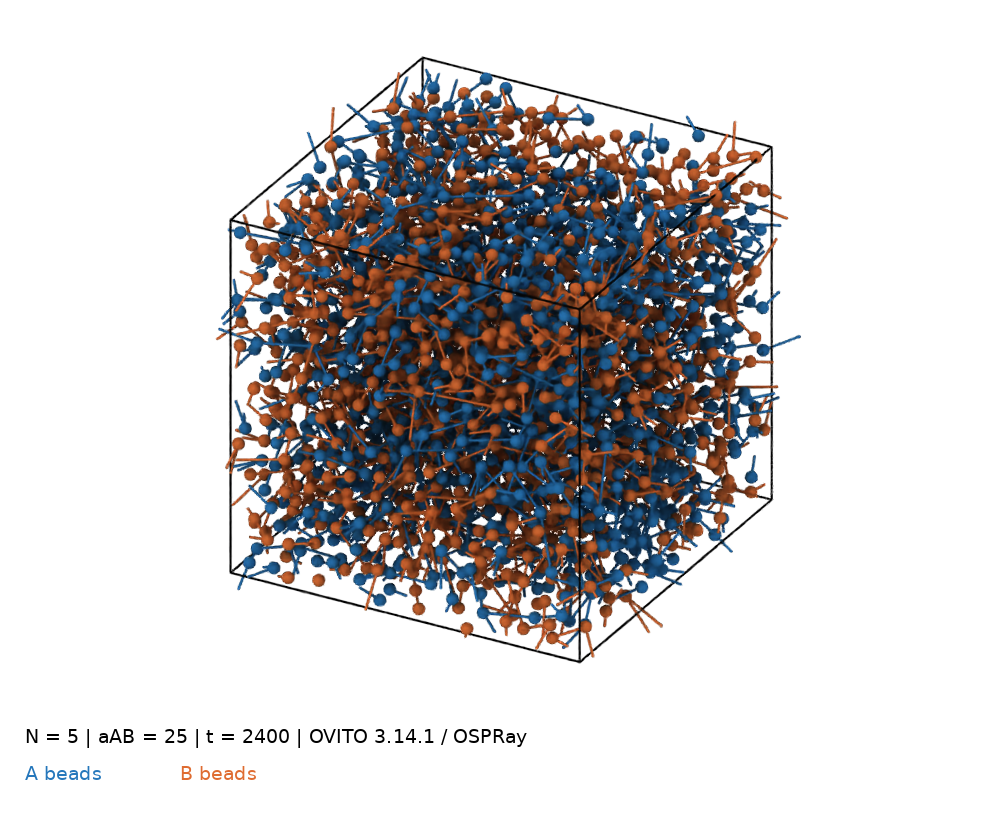

```python
#!/usr/bin/env python3
"""Reproduce Part D tables, figures and convergence checks from saved data."""
from pathlib import Path
import json,csv
import numpy as np
import matplotlib.pyplot as plt
ROOT=Path.cwd();SERIES={3:[3,5,7],5:[2,3.5,5],10:[1,1.5,2]}
def tag(n,a):return f'd_n{n}_a{a:g}'.replace('.','p')
def load(name):return np.atleast_1d(np.genfromtxt(ROOT/name,delimiter=',',names=True))
def manifest(t):return json.loads((ROOT/f'data/{t}_manifest.json').read_text())
def reblock(v):
    v=np.asarray(v,float);rows=[]
    for q in [1,2,4]:
        nb=len(v)//q
        if nb>=4:
            z=v[:nb*q].reshape(nb,q).mean(axis=1)
            rows.append((q,nb,float(z.std(ddof=1)/np.sqrt(nb))))
    if not rows:raise ValueError('Need at least four complete production blocks')
    return max(row[2] for row in rows),rows

def savefig(fig,name):
    fig.tight_layout();fig.savefig(ROOT/name,dpi=180)
    try:
        from IPython import get_ipython
        from IPython.display import display
        if get_ipython() is not None:display(fig)
    except ImportError:pass
    plt.close(fig)
def write_table(name,rows):
    with (ROOT/name).open('w',newline='') as f:
        writer=csv.DictWriter(f,fieldnames=list(rows[0]));writer.writeheader();writer.writerows(rows)
def print_table(rows,keys):
    print(' | '.join(keys))
    for row in rows:print(' | '.join(f'{row[k]:.6g}' if isinstance(row[k],(float,np.floating)) else str(row[k]) for k in keys))

def snapshot(t,name,chains=False):
    # OVITO renders the saved final PDB coordinates; reuse those verified images.
    # Regenerate explicitly with: python scripts/render_d_ovito.py
    path=ROOT/name
    if not path.exists():raise FileNotFoundError(f'{path}: run scripts/render_d_ovito.py first')
    try:
        from IPython import get_ipython
        from IPython.display import Image, display
        if get_ipython() is not None:display(Image(filename=str(path)))
    except ImportError:pass

def d1():
    m=manifest('d1');b=load('data/d1_chain_blocks.csv');v=b['Re2'][b['production']==1]
    e,rb=reblock(v);ideal=3*(m['chain_length']-1)*m['kT']/m['C']
    half=len(v)//2;first,last=v[:half].mean(),v[half:].mean()
    row=dict(N=m['chain_length'],steps=m['steps'],discard_steps=m['equil'],blocks=len(v),Re2=float(v.mean()),Re2_SE=e,ideal_Re2=ideal,
             mean_bond2=float(b['bond2'][b['production']==1].mean()),first_half=float(first),second_half=float(last))
    write_table('data/D1_chain_size.csv',[row]);print_table([row],list(row))
    fig,axes=plt.subplots(1,2,figsize=(10,4))
    axes[0].plot(b['t_end'],b['Re2'],'o-');axes[0].axhline(ideal,color='black',ls='--',label='Ideal springs, imposed kBT')
    axes[0].axvline(m['equil']*m['dt'],color='grey',ls=':');axes[0].set(xlabel='Time',ylabel='Block mean end-to-end distance squared');axes[0].legend()
    axes[1].plot([q*m['block']*m['dt'] for q,nb,se in rb],[se for q,nb,se in rb],'o-');axes[1].set(xlabel='Merged block duration',ylabel='SE of mean Re²')
    savefig(fig,'data/D1_chain_convergence.png');snapshot('d1','data/D1_snapshot.png',True)
    (ROOT/'data/D1_summary.json').write_text(json.dumps(row,indent=2));return row

def profile(t,cut=None):
    m=manifest(t);raw=load(f'data/{t}_profile_blocks.csv');groups=[raw[raw['block']==b] for b in np.unique(raw['block'])]
    x=groups[0]['x'];a=np.array([g['rho_A'] for g in groups]);b=np.array([g['rho_B'] for g in groups]);end=np.array([g['t_end'][0] for g in groups]);start=np.array([g['t_start'][0] for g in groups])
    assert all(len(g)==len(x) and np.allclose(g['x'],x) for g in groups)
    assert len({g['frames'][0] for g in groups})==1
    L=m['L'][0];cut=m['equil']*m['dt'] if cut is None else cut;keep=start>=cut-1e-9
    scale=(x[1]-x[0])*m['L'][1]*m['L'][2]
    assert np.allclose(a.sum(axis=1)*scale,m['num_part']/2) and np.allclose(b.sum(axis=1)*scale,m['num_part']/2)
    def fraction(lo,hi,component):
        w=(x>=lo*L)&(x<hi*L)
        return (a if component=='A' else b)[:,w].sum(axis=1)/(a+b)[:,w].sum(axis=1)
    minority=fraction(.7,.8,'A');opposite=fraction(.2,.3,'B');wide=fraction(.65,.85,'A')
    return dict(m=m,x=x,a=a,b=b,phi=a/(a+b),end=end,keep=keep,cut=cut,v=minority,opposite=opposite,wide=wide,
                aligned=np.array([g['aligned_fraction'][0] for g in groups]))

def diagnostics(d):
    k=d['keep'];v=d['v'][k];se,rb=reblock(v);half=len(v)//2
    s1,_=reblock(v[:half]);s2,_=reblock(v[half:]);den=np.hypot(s1,s2)
    drift=float(abs(v[:half].mean()-v[half:].mean()));drift_z=drift/den if den>0 else float('inf')
    delta=v-d['wide'][k];delta_se,_=reblock(delta);sym=v-d['opposite'][k];symse,_=reblock(sym)
    x=d['x'];a=d['a'][k];b=d['b'][k];L=d['m']['L'][0]
    def subwindow(lo,hi):
        w=(x>=lo*L)&(x<hi*L)
        return a[:,w].sum(axis=1)/(a+b)[:,w].sum(axis=1)
    central=subwindow(.7,.75)-subwindow(.75,.8);central_se,_=reblock(central)
    flags=[]
    if drift_z>3:flags.append('production-half drift')
    if d['aligned'][k].min()<.95:flags.append('weak/absent x slab')
    if abs(delta.mean())>max(3*delta_se,.1*v.mean()):flags.append('bulk-window sensitivity')
    if abs(central.mean())>max(3*central_se,.1*v.mean()):flags.append('nonflat central bulk')
    if abs(sym.mean())>max(3*symse,.1*v.mean()):flags.append('A/B asymmetry')
    if not 0<v.mean()<.5:flags.append('no valid minority plateau')
    return dict(phi=float(v.mean()),phi_SE=se,drift=drift,drift_z=drift_z,window_difference=float(delta.mean()),window_difference_SE=delta_se,
                opposite_phi=float(d['opposite'][k].mean()),symmetry_difference_SE=symse,central_difference=float(central.mean()),central_difference_SE=central_se,zero_minority_blocks=int(np.count_nonzero(v<=0)),flags='; '.join(flags) or 'none'),rb

def d2():
    fig,axes=plt.subplots(1,2,figsize=(11,4));rows=[]
    for n in [3,5,10]:
        d=profile(tag(n,28));k=d['keep'];A=d['a'][k].mean(axis=0);B=d['b'][k].mean(axis=0);z,rb=diagnostics(d)
        axes[0].plot(d['x'],A/(A+B),label=f'N={n}')
        axes[1].plot(d['end'],d['v'],'o-',ms=3,label=f'N={n}')
        rows.append(dict(N=n,**z));snapshot(tag(n,28),f'data/D2_snapshot_N{n}.png')
    axes[0].set(xlabel='x / rc',ylabel='A bead fraction',ylim=(0,1));axes[0].legend()
    axes[1].set(xlabel='Time',ylabel='A fraction in B-rich central window');axes[1].legend();axes[1].axvline(d['cut'],color='grey',ls=':')
    savefig(fig,'data/D2_profiles.png');write_table('data/D2_diagnostics.csv',rows);print_table(rows,['N','phi','phi_SE','drift_z','flags']);return rows

def chiN(p):return np.log((1-p)/p)/(1-2*p)
def d3():
    rows=[];rbrows=[];fig,axes=plt.subplots(3,3,figsize=(12,10),sharex=True,sharey=True)
    fig2,axes2=plt.subplots(3,1,figsize=(9,9))
    for row,(n,deltas) in enumerate(SERIES.items()):
        for col,delta in enumerate(deltas):
            t=tag(n,25+delta);d=profile(t);k=d['keep'];v=d['v'][k];z,rbs=diagnostics(d)
            if not 0<z['phi']<.5:raise ValueError(f'{t}: cannot extract chi from absent coexistence')
            est=float(chiN(z['phi']));errors=[]
            for q,nb,se in rbs:
                values=v[:q*nb].reshape(nb,q).mean(axis=1);loo=(values.sum()-values)/(nb-1)
                if np.any(loo<=0):raise ValueError(f'{t}: insufficient minority counts')
                estimates=chiN(loo);err=float(np.sqrt((nb-1)/nb*np.sum((estimates-estimates.mean())**2)));errors.append(err)
                rbrows.append(dict(N=n,delta_a=delta,merge=q,blocks=nb,block_time=q*d['m']['block']*.04,phi_SE=se,chiN_SE=err))
            err=max(errors)
            rows.append(dict(N=n,delta_a=delta,aAB=25+delta,**z,chi=est/n,chi_SE=err/n,chiN=est,chiN_SE=err,ratio=est/delta,ratio_SE=err/delta,
                             paper_ratio=.306*n,discard_time=d['cut'],steps=d['m']['steps'],blocks=int(k.sum())))
            ax=axes[row,col];meanA=d['a'][k].mean(axis=0);meanB=d['b'][k].mean(axis=0)
            ax.plot(d['x'],meanA/(meanA+meanB));ax.axvspan(14,16,color='orange',alpha=.2);ax.axvspan(4,6,color='blue',alpha=.12)
            ax.set(title=f'N={n}, Δa={delta:g}',xlabel='x / rc',ylabel='A bead fraction',ylim=(0,1))
            axes2[row].plot(d['end'],d['v'],'o-',ms=3,label=f'Δa={delta:g}')
        axes2[row].axvline(d['cut'],color='grey',ls=':');axes2[row].set(xlabel='Time',ylabel='Minority bead fraction',title=f'N={n}');axes2[row].legend()
    savefig(fig,'data/D3_profiles.png');savefig(fig2,'data/D3_bulk_convergence.png')
    write_table('data/D3_table.csv',rows);write_table('data/D3_reblocking.csv',rbrows)
    fig,ax=plt.subplots(figsize=(8,5));xx=np.linspace(2,11,100)
    ax.plot(xx,.306*xx,'k--',label='Groot & Warren Eq. (27): 0.306 N')
    ax.fill_between(xx,.303*xx,.309*xx,color='grey',alpha=.2,label='Published coefficient ±0.003')
    for n in SERIES:
        group=[r for r in rows if r['N']==n]
        offsets=np.linspace(-.18,.18,len(group))
        for off,r in zip(offsets,group):
            ax.errorbar(n+off,r['ratio'],yerr=r['ratio_SE'],fmt='o',capsize=3,label=f'N={n}, Δa={r["delta_a"]:g}'+(' (check)' if r['flags']!='none' else ''))
    ax.set(xlabel='Chain length N (points offset slightly for visibility)',ylabel='χN / Δa',xticks=[3,5,10]);ax.legend(fontsize=8,ncol=2)
    savefig(fig,'data/D3_chi_comparison.png');print_table(rows,['N','delta_a','phi','phi_SE','chi','chi_SE','chiN','chiN_SE','drift_z','flags'])
    print('Flags require inspection or more sampling; agreement with a line does not establish equilibration.')
    return rows

D1_RESULTS=d1()
```

### D2 — Demixing at the same excess repulsion

We used $N=3,5,10$ at $Δa=3$ ($aAB=28$), with $aAA=aBB=25$, 6000 beads, density 3, and the periodic $20×10×10$ box. The initially separated A/B chains form interfaces normal to $x$. Each run lasted 60,000 steps ($t=2400$); the first 20,000 steps ($t=800$) were discarded. The remaining 16 blocks each span 2500 steps ($t=100$).

The common-axis figure shows the **bead fraction** of A, not the fraction of chain centres. Profiles are registered by a periodic translation along $x$ using the first composition Fourier mode, as in Part C; no rotation is applied. There are two interfaces, near $x=10$ and across the periodic boundary. The three snapshots below are OVITO/OSPRay renderings of the final saved configurations ($t=2400$), with A blue and B orange. Their coordinates are unshifted; the composition profiles are registered as described above.

| Chain length N | A fraction in B-rich bulk | Block SE | Production-half difference / combined SE |
| --- | --- | --- | --- |
| 3 | 0.129736 | 0.015602 | 1.57 |
| 5 | 0.017981 | 0.002180 | 0.53 |
| 10 | 0.000085 | 0.000052 | 1.41 |

The bulk windows are $4≤x<6$ and $14≤x<16$, far from the registered interfaces. We check production-half drift, widening the B window to $13≤x<17$, A/B symmetry, and whether the x slab remains identifiable. The diagnostic table printed below records any flags; a flag must be investigated rather than treated as proof of equilibrated coexistence. The images alone cannot establish equilibrium.

Diagnostics to investigate: N=10: bulk-window sensitivity.

For N=10 at Δa=3, some blocks have no minority beads in the central B window, and the wider-window check is sensitive to rare beads/interfacial tails. The profile and snapshot still show strong separation, but this run is not used to claim a precise χ value. D3 uses the weaker repulsions prescribed for N=10.

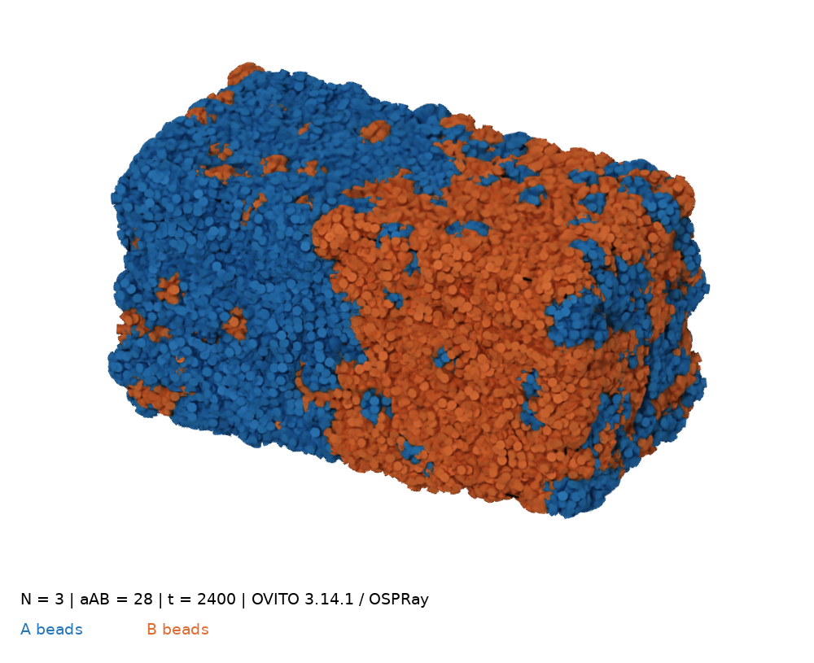

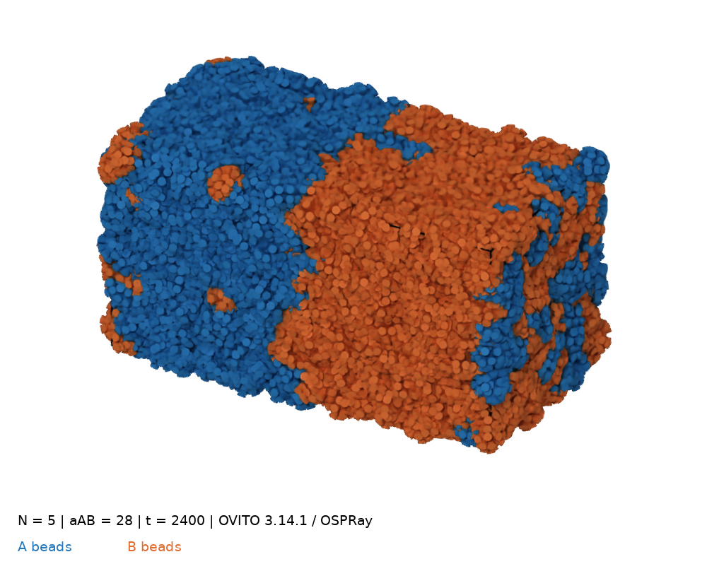

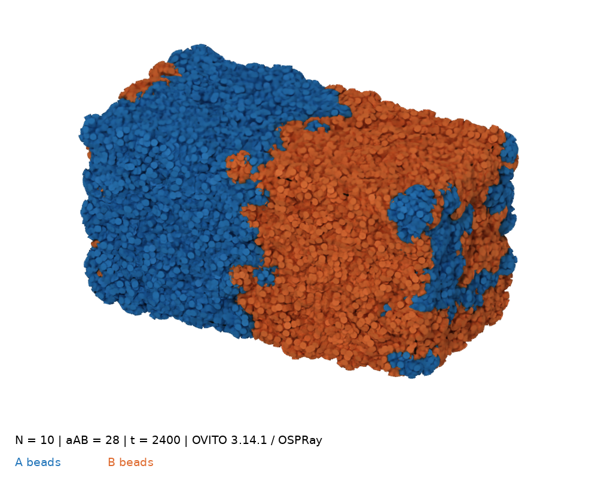

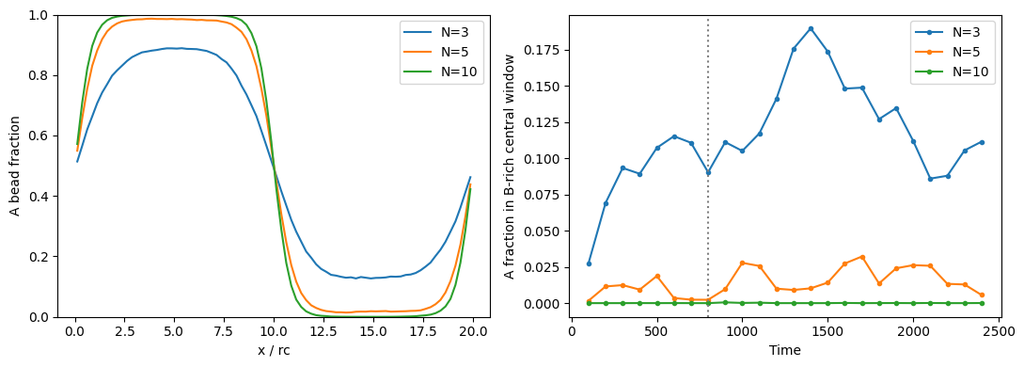

```
N | phi | phi_SE | drift_z | flags
3 | 0.129736 | 0.0156016 | 1.56973 | none
5 | 0.0179806 | 0.00217963 | 0.528906 | none
10 | 8.49977e-05 | 5.19614e-05 | 1.41435 | bulk-window sensitivity
```

```python
D2_RESULTS=d2()
```

### D3 — χ for chains and why longer chains demix more readily

For the symmetric blend, Eq. (18) measures the **product** $χN$:

$$χN=ln[(1−ϕA)/ϕA]1−2ϕA,χ=1Nln[(1−ϕA)/ϕA]1−2ϕA.$$

Here $ϕA$ is the A **bead fraction in the B-rich bulk**, read from $14≤x<16$. It is neither the overall fraction 0.5 nor a chain-centre fraction. The required series is $Δa=3,5,7$ for $N=3$; $2,3.5,5$ for $N=5$; and $1,1.5,2$ for $N=10$. The $N=3$, $Δa=3$ case reuses D2 data. All nine runs use the D2 box, density and time step. Most use 60,000 steps and discard 20,000. The N=5 runs at Δa=2 and 5 were extended to 120,000 steps, with 40,000 discarded, after drift/rare-minority diagnostics. Their actual discard times and retained block counts are saved in `D3_table.csv`.

| N | Δa | Bulk A fraction | SE of fraction | χ | SE of χ | χN | SE of χN |
| --- | --- | --- | --- | --- | --- | --- | --- |
| 3 | 3 | 0.129736 | 0.015602 | 0.85673 | 0.02686 | 2.57019 | 0.08058 |
| 3 | 5 | 0.013125 | 0.002912 | 1.47884 | 0.07275 | 4.43651 | 0.21826 |
| 3 | 7 | 0.001119 | 0.000429 | 2.26979 | 0.12500 | 6.80938 | 0.37499 |
| 5 | 2 | 0.067851 | 0.005179 | 0.60631 | 0.01180 | 3.03157 | 0.05902 |
| 5 | 3.5 | 0.007017 | 0.001814 | 1.00456 | 0.05156 | 5.02282 | 0.25779 |
| 5 | 5 | 0.000172 | 0.000128 | 1.73469 | 0.25272 | 8.67346 | 1.26361 |
| 10 | 1 | 0.104505 | 0.012556 | 0.27158 | 0.00814 | 2.71576 | 0.08143 |
| 10 | 1.5 | 0.018117 | 0.006956 | 0.41427 | 0.04091 | 4.14273 | 0.40906 |
| 10 | 2 | 0.001629 | 0.001163 | 0.64390 | 0.10847 | 6.43896 | 1.08471 |

Errors account for correlations by merging consecutive production blocks in groups of 1, 2 and 4 (durations 100, 200 and 400), retaining the largest supported standard error. For the nonlinear χ calculation, we use a delete-one block jackknife at each merged block size and retain the largest error. For the 60,000-step runs there are 16, 8 and 4 merged blocks; the extended runs have 32, 16 and 8. The largest-block estimate is itself imprecise. These errors do not include all finite-box, bulk-window or model-mapping biases. Zero counts in individual base blocks are retained as observations. The pooled minority fraction and every delete-one estimate must remain positive; no pseudocount is added to make a logarithm finite. Rare-minority counts are listed below and qualify the precision of strongly segregated cases.

Eq. (18) assumes steady two-phase coexistence, homogeneous bulk regions away from both interfaces, and equal chain lengths. The nine profiles, bulk histories, production-half comparison and window/symmetry checks below assess these conditions for each run; a separated initial configuration is not sufficient.

As a separate flatness check, we compare the left and right halves of the chosen central bulk window with a paired block error. The CSV records that difference and its SE. A wider-window warning can indicate interfacial tails in the wider region even when the chosen central region is consistent with a flat plateau; it is retained as a systematic-sensitivity qualification.

**Rare-minority sampling:** N=3, Δa=7: 4 zero-minority base blocks out of 16; N=5, Δa=5: 22 zero-minority base blocks out of 32. The finite jackknife errors describe the pooled estimate, but a Gaussian error bar may not fully describe the skewed uncertainty.

**Checks requiring follow-up:** N=5, Δa=5: bulk-window sensitivity; N=10, Δa=1.5: bulk-window sensitivity; N=10, Δa=2: bulk-window sensitivity. These χ estimates are provisional.

We compare $χN/Δa$ against chain length, in the format of Fig. 8. Groot and Warren's Eq. (27), in our reduced units, gives

$$χNΔa=(0.306±0.003)N.$$

The dashed line and shaded band below show that published fit and its coefficient uncertainty; they are not digitized Fig. 8 measurements. The source is the [author-uploaded paper](https://www.researchgate.net/publication/257993073_Dissipative_particle_dynamics_Bridging_the_gap_between_atomistic_and_mesoscopic_simulation), Eq. (27) and the surrounding discussion (see `data/reference/D_reference.md`). $N=10$ is at the edge of the reported short-chain fitting range. The figure reports every required series point, with sampling error bars; visual proximity to the line does not replace the convergence checks.

At fixed $Δa$, the repulsion cost per bead changes little with chain length, but the entropy gained by mixing is reduced because linked beads do not mix independently. The symmetric Flory–Huggins free energy per bead has mixing entropy $[ϕlnϕ+(1−ϕ)ln(1−ϕ)]/N$ and an energetic contribution $χϕ(1−ϕ)$. Consequently the relevant balance is $χN$, with mean-field critical value 2; the actual finite DPD fluid need not have exactly that critical value. Longer chains reach the demixing regime at smaller $Δa$.

The measured ratios span the following ranges across the three repulsions for each N (the plot carries the individual error bars):

| N | Measured χN/Δa range | Eq. (27) |
| --- | --- | --- |
| 3 | 0.857–0.973 | 0.918 |
| 5 | 1.435–1.735 | 1.530 |
| 10 | 2.716–3.219 | 3.060 |

The overall rise with N is consistent with the paper mapping. Individual deviations and the near-critical/rare-minority sampling limits remain visible, so this is a comparison with an empirical short-chain fit rather than a claim of exact reproduction.